# Experiment 1

Self-Priority Effects on Nonspatial Working Memory

Woojeong Lee & Do-Joon Yi

2025-05-28

```r
pacman::p_load(tidyverse, psych, knitr, rstatix, BayesFactor, Superpower)
pacman::p_load(gghalves, ggpubr, see, cowplot)
pacman::p_load_gh("thomasp85/patchwork", "rlesur/klippy")
if (!requireNamespace("Rmisc", quietly = TRUE)) install.packages("Rmisc") # never load directly

set.seed(1234567) # for reproducibility
options(dplyr.summarise.inform=FALSE) # suppress warning in regards to regrouping
options(knitr.kable.NA = '')
options("scipen" = 100) # https://rfriend.tistory.com/224
nIter <- 1e6 # Monte Carlo simulations for error < 1%. default = 1e4
tOff <- 2.5 # RTtrimming
klippy::klippy()
```

```r
# Excluding Ss
rm_subject <- function(df, rx){
  for (i in rx){
    df <- df %>% filter(SN != i) %>% droplevels()
  }
  cat(sprintf('%d removed & %d left',
              length(unique(rx)),
              length(unique(df$SN))))
  return(df)
}

# Plot for outlier check
# stat summary plot to 25% quartile and 75% quartile
# https://bit.ly/3iFpV07
single_raincloud_plot <- function(df, Y, xMin, xMax, xBy, xLab){
  df %>% ggplot(aes(x = 1, y = Y)) +
    geom_half_violin(aes(y = Y), side = "r",
                     color = "grey70", fill = "grey70") +
    geom_half_point(aes(y = Y), side = "l", size = 2,
                    color = "grey50", fill = "grey50", alpha = .5) +
    geom_pointrange(stat = "summary",
                    fun.min = function(z) {quantile(z,0.25)},
                    fun.max = function(z) {quantile(z,0.75)},
                    fun = median, color = "darkred", size = 1) +
    scale_y_continuous(breaks=seq(xMin,xMax,by=xBy)) +
    coord_flip(ylim = c(xMin, xMax), clip = "on") +
    labs(y = xLab) +
    theme_bw(base_size = 16) +
    theme(panel.grid.major = element_blank(),
          panel.grid.minor = element_blank(),
          axis.title.y = element_blank(),
          axis.ticks.y = element_blank(),
          axis.text.y = element_blank(),
          aspect.ratio = .3)
}

## Plot for results
plotMatchLabel <- function(df, ylabel, ymin, ymax, yby,
                           OminusS, ymin2, ymax2, yby2) {
  names(df)[ncol(df)] <- "DV" # assuming DV on the last column

  df.g <- df %>%
    Rmisc::summarySEwithin(measurevar = 'DV', idvar = 'SN',
                           withinvars = c("Matching", "Label"))

  df.w <- df %>%
    unite("temp", c("Matching", "Label")) %>%
    pivot_wider(id_cols = SN, names_from = temp, values_from = DV)

  doff <- 0.03
  tmp <- runif(nrow(df.w), -doff, doff)
  spd1 <- rep(-0.14,nrow(df.w)) + tmp
  spd2 <- rep( 0.14,nrow(df.w)) + tmp

  F1 <- ggplot() +
    geom_bar(data=df.g, aes(x = Matching, y = DV, fill = Label),
             stat="identity", width=0.7, color="black", position=position_dodge(.8)) +
    scale_fill_manual(values=c('#E69F00', '#56B4E9'),
                      labels=c("Self", "Stranger")) +
    geom_segment(data=df.w, color="black", alpha = 0.3,
                 aes(x=1+spd1, y=Match_Self, xend=1+spd2, yend=Match_Stranger)) +
    geom_segment(data=df.w, color="black", alpha = 0.3,
                 aes(x=2+spd1, y=Nonmatch_Self, xend=2+spd2, yend=Nonmatch_Stranger)) +
    geom_linerange(data=df.g, aes(x=Matching, ymin=DV-ci, ymax=DV+ci, group=Label),
                   linewidth=1, position=position_dodge(0.8)) +
    labs(x = "Matching", y = ylabel, fill='Label ') +
    coord_cartesian(ylim = c(ymin, ymax), clip = "on") +
    scale_y_continuous(breaks=seq(ymin, ymax, by = yby)) +
    theme_bw(base_size = 18) +
    theme(legend.position="top",
          legend.spacing.x = unit(0.5, 'lines'),
          legend.margin = margin(0, 0, 0, 0),
          legend.background = element_blank(),
          panel.grid.major = element_blank(),
          panel.grid.minor = element_blank())

  if (OminusS) { # Boolean: Stranger - Self
    df2.w <- df.w %>%
      mutate(Match = Match_Stranger - Match_Self,
             Nonmatch = Nonmatch_Stranger - Nonmatch_Self) %>%
      select(SN, Match, Nonmatch)
  } else {
    df2.w <- df.w %>%
      mutate(Match = Match_Self - Match_Stranger,
             Nonmatch = Nonmatch_Self - Nonmatch_Stranger) %>%
      select(SN, Match, Nonmatch)
  }

  df2 <- df2.w %>%
    pivot_longer(cols = c(Match, Nonmatch), names_to = "Matching", values_to = "SPE")

  df2.g <- df2 %>%
    mutate(Matching = factor(Matching)) %>%
    Rmisc::summarySEwithin(measurevar = "SPE", withinvars = "Matching", idvar = "SN")

  moff <- 0.1
  doff <- 0.05
  vpd <- rep(c(1-moff, 2+moff), nrow(df2)/2) # violin position dodge
  dpd <- rep(c(1+moff, 2-moff), nrow(df2)/2) + # dot position dodge
    rep(runif(nrow(df2)/2, -doff, doff), each=2)

  F2 <- cbind(df2, vpd, dpd) %>%
    ggplot(aes(x = Matching, y = SPE, group = Matching)) +
    geom_pointrange(data=df2.g, aes(x = Matching, ymin = SPE-ci, ymax = SPE+ci),
                    linewidth = 1, color = "black") +
    geom_point(data=df2.g, aes(x = Matching, y = SPE),
               size=3, color = "black", show.legend = FALSE) +
    geom_hline(yintercept = 0) +
    geom_violinhalf(aes(x = vpd, y = SPE, group = Matching),
                    flip = c(1,3), width = 0.7, fill = "gray70") +
    # geom_point(aes(x = dpd, y = SPE, group = SN), alpha = 0.3) +
    geom_line(aes(x = dpd, y = SPE, group = SN), color = "black", alpha = 0.3) +
    labs(x = "Matching",
         y = ifelse (OminusS, # Boolean: Stranger - Self
                     expression(paste("SPE" [" Stranger - Self"])),
                     expression(paste("SPE" [" Self - Stranger"])))) +
    coord_cartesian(ylim = c(ymin2, ymax2), clip = "on") +
    scale_y_continuous(breaks=seq(ymin2, ymax2, by = yby2)) +
    theme_bw(base_size = 18) +
    theme(panel.grid.major = element_blank(),
          panel.grid.minor = element_blank())

  F1 + F2 + plot_layout(nrow = 1, widths = c(2, 1.2))
}

plotOrderLabel <- function(df, ylabel, ymin, ymax, yby,
                            OminusS, ymin2, ymax2, yby2) {
  # assuming 1-4: SN, Order, Label, DV
  names(df)[ncol(df)] <- "DV" # assuming DV on the last column

  df.g <- df %>%
    Rmisc::summarySEwithin(measurevar = 'DV', idvar = 'SN',
                           withinvars = c("Order", "Label"))

  df.w <- df %>%
    unite("temp", c("Order", "Label")) %>%
    pivot_wider(id_cols = SN, names_from = temp, values_from = DV)

  doff <- 0.03
  tmp <- runif(nrow(df.w), -doff, doff)
  spd1 <- rep(-0.14,nrow(df.w)) + tmp
  spd2 <- rep( 0.14,nrow(df.w)) + tmp

  F1 <- ggplot() +
    geom_bar(data=df.g, aes(x = Order, y = DV, fill = Label),
             stat="identity", width=0.7, color="black", position=position_dodge(.8)) +
    scale_fill_manual(values=c('#E69F00', '#56B4E9'),
                      labels=c("Self", "Stranger")) +
    geom_segment(data=df.w, color="black", alpha = 0.3,
                 aes(x=1+spd1, y=First_Self, xend=1+spd2, yend=First_Stranger)) +
    geom_segment(data=df.w, color="black", alpha = 0.3,
                 aes(x=2+spd1, y=Second_Self, xend=2+spd2, yend=Second_Stranger)) +
    geom_linerange(data=df.g, aes(x=Order, ymin=DV-ci, ymax=DV+ci, group=Label),
                   linewidth=1, position=position_dodge(0.8)) +
    labs(x = "Order", y = ylabel, fill='Label ') +
    coord_cartesian(ylim = c(ymin, ymax), clip = "on") +
    scale_y_continuous(breaks=seq(ymin, ymax, by = yby)) +
    theme_bw(base_size = 18) +
    theme(legend.position="top",
          legend.spacing.x = unit(0.5, 'lines'),
          legend.margin = margin(0, 0, 0, 0),
          legend.background = element_blank(),
          panel.grid.major = element_blank(),
          panel.grid.minor = element_blank())

  if (OminusS) { # Boolean: Stranger - Self
    df2.w <- df.w %>%
      mutate(First = First_Stranger - First_Self,
             Second = Second_Stranger - Second_Self) %>%
      select(SN, First, Second)
  } else {
    df2.w <- df.w %>%
      mutate(First = First_Self - First_Stranger,
             Second = Second_Self - Second_Stranger) %>%
      select(SN, First, Second)
  }

  df2 <- df2.w %>%
    pivot_longer(cols = c(First, Second), names_to = "Order", values_to = "SPE")

  df2.g <- df2 %>%
    mutate(Order = factor(Order)) %>%
    Rmisc::summarySEwithin(measurevar = "SPE", withinvars = "Order", idvar = "SN")

  moff <- 0.1
  doff <- 0.05
  vpd <- rep(c(1-moff, 2+moff), nrow(df2)/2) # violin position dodge
  dpd <- rep(c(1+moff, 2-moff), nrow(df2)/2) + # dot position dodge
    rep(runif(nrow(df2)/2, -doff, doff), each=2)

  F2 <- cbind(df2, vpd, dpd) %>%
    ggplot(aes(x = Order, y = SPE, group = Order)) +
    geom_pointrange(data=df2.g, aes(x = Order, ymin = SPE-ci, ymax = SPE+ci),
                    linewidth = 1, color = "black") +
    geom_point(data=df2.g, aes(x = Order, y = SPE),
               size=3, color = "black", show.legend = FALSE) +
    geom_hline(yintercept = 0) +
    geom_violinhalf(aes(x = vpd, y = SPE, group = Order),
                    flip = c(1,3), width = 0.7, fill = "gray70") +
    # geom_point(aes(x = dpd, y = SPE, group = SN), alpha = 0.3) +
    geom_line(aes(x = dpd, y = SPE, group = SN), color = "black", alpha = 0.3) +
    labs(x = "Order",
         y = ifelse (OminusS, expression(paste("SPE" [" Stranger - Self"])),
                     expression(paste("SPE" [" Self - Stranger"])))) +
    coord_cartesian(ylim = c(ymin2, ymax2), clip = "on") +
    scale_y_continuous(breaks=seq(ymin2, ymax2, by = yby2)) +
    theme_bw(base_size = 18) +
    theme(panel.grid.major = element_blank(),
          panel.grid.minor = element_blank())

  F1 + F2 + plot_layout(nrow = 1, widths = c(2, 1.2))
}
```

# 1 Power Analysis

We conducted a simulation to determine the sample size based on the publicly available [dataset](https://osf.io/9ua8f) provided by [Yin et al. (2019, Experiment 2)](https://doi.org/10.1177/0956797618818483). Their study employed a 2 (serial order: first, second) × 3 (social association: self, friend, stranger) within-subjects design; thus, we excluded trials from the friend condition to match our 2 (serial order: first, second) × 2 (social association: self and stranger) design. Given the means, standard deviations, and inter-condition correlations of response times (RTs) across the four conditions, we estimated the sample size required to achieve 90% power to detect a main effect of social association in a 2 × 2 repeated-measures ANOVA using the [Superpower](https://cran.r-project.org/web/packages/Superpower/vignettes/intro_to_superpower.html) package (Lakens & Caldwell, 2021).

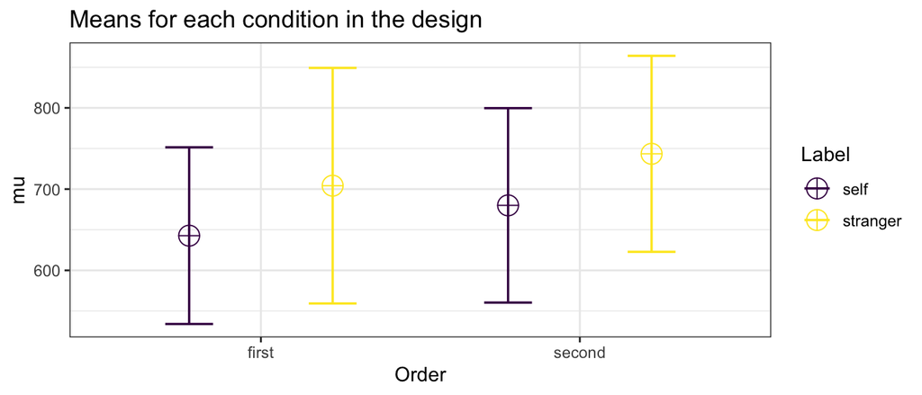

```r
ef2 <- read.csv("data/Yin2019Exp2n27.csv", header = TRUE) %>%
  select(ExperimentName,
         Subject,
         item1, # WM pic
         item2, # WM pic
         probe, # probe pic
         matchWM,
         order,
         probe.ACC,
         probe.RT,
         condition,
         judge, # label; loc_label
         rSelf, # 1=Match, 2=Nonmatch
         judge.ACC,
         judge.RT) %>%
  rename(Group = ExperimentName,
         SN = Subject,
         Order = order,
         wmACC = probe.ACC,
         wmRT = probe.RT,
         cond = condition,
         speACC = judge.ACC,
         speRT = judge.RT) %>%
  filter(matchWM == "mat") %>%
  separate_wider_delim("judge", delim = "_", names = c(NA, "Label")) %>%
  separate_wider_delim("Group", delim = "_", names = c(NA, "Grp", NA)) %>%
  separate_wider_position("Grp", c("Self" = 1, "Friend" = 1, "Stranger" = 1)) %>%
  separate_wider_position("item1", c("item1" = 1, "loc1" = 1)) %>%
  separate_wider_position("item2", c("item2" = 1, "loc2" = 1)) %>%
  separate_wider_position("probe", c(6, "probe" = 1)) %>%
  mutate("probed" = ifelse(probe == loc1, item1, item2)) %>%
  mutate("Condition" = ifelse(probed == Self, "self", ifelse(probed == Friend, "friend", "stranger"))) %>%
  mutate(speMatch = ifelse(rSelf==1, "match", "nonmatch")) %>%
  group_by(SN) %>%
  mutate(Trial = row_number()) %>%
  ungroup() %>%
  select(SN, Trial, Order, Condition, wmACC, wmRT, cond, Label, speMatch, speACC, speRT) %>%
  mutate(SN = factor(SN),
         Order = factor(Order),
         Condition = factor(Condition,
                            levels = c("self", "friend", "stranger"),
                            labels = c("self", "friend", "stranger")),
         speMatch = factor(speMatch))
ef2
## # A tibble: 5,832 × 11
##    SN    Trial Order  Condition wmACC  wmRT cond     Label speMatch speACC speRT
##    <fct> <int> <fct>  <fct>     <int> <int> <chr>    <chr> <fct>     <int> <int>
##  1 1         1 first  stranger      1  1047 strange… frie… nonmatch      1   703
##  2 1         2 second friend        1   714 friend_… stra… nonmatch      1   705
##  3 1         3 first  stranger      0   822 strange… self  nonmatch      0     0
##  4 1         4 first  self          1   786 self_fr… stra… nonmatch      1   678
##  5 1         5 first  friend        1  1330 friend_… frie… match         1   655
##  6 1         6 first  self          1   713 self_st… stra… nonmatch      1   657
##  7 1         7 first  friend        1   774 friend_… frie… match         1   922
##  8 1         8 second stranger      0  1171 strange… stra… match         0     0
##  9 1         9 second self          1   618 self_st… self  match         1   613
## 10 1        10 first  friend        1   620 friend_… stra… nonmatch      1   735
## # ℹ 5,822 more rows
length(unique(ef2$SN))
## [1] 27

ef2wt <- ef2 %>%
  filter(wmACC == 1) %>%
  group_by(SN, Order, Condition) %>%
  nest() %>%
  mutate(lbound = map(data, ~mean(.$wmRT)-2.5*sd(.$wmRT)),
         ubound = map(data, ~mean(.$wmRT)+2.5*sd(.$wmRT))) %>%
  unnest(c(lbound, ubound)) %>%
  unnest(data) %>%
  mutate(Outlier = (wmRT < lbound)|(wmRT > ubound)) %>%
  filter(Outlier == FALSE) %>%
  ungroup() %>%
  select(SN, Order, Condition, wmRT)

table(ef2wt$Order, ef2wt$SN)
##
##            1   2   3   4   5   6   7   8   9  10  11  12  13  14  15  16  17
##   first   94 104 102 105 103 104 101 104 104 103 103 103 101  97 101  98 103
##   second  89 103 104 102 101 103  98 104 106 101 104 100  99  88 103 103 102
##
##           18  19  20  21  22  23  24  25  26  27
##   first  106 104 105 103 104 104 104 106 106 103
##   second 107 102 105 105 103 101 104 102 106 103
table(ef2wt$Condition, ef2wt$SN)
##
##             1  2  3  4  5  6  7  8  9 10 11 12 13 14 15 16 17 18 19 20 21 22 23
##   self     65 68 69 69 68 70 67 69 70 65 69 68 67 63 67 68 69 70 68 69 71 68 69
##   friend   60 67 70 69 68 68 65 71 70 71 69 67 66 62 68 67 67 72 68 70 70 69 68
##   stranger 58 72 67 69 68 69 67 68 70 68 69 68 67 60 69 66 69 71 70 71 67 70 68
##
##            24 25 26 27
##   self     69 68 71 68
##   friend   70 70 71 69
##   stranger 69 70 70 69

ef2wt.ind <- ef2wt %>%
  group_by(SN, Order, Condition) %>%
  summarise(M = mean(wmRT)) %>%
  ungroup()

ef2wt.ind %>%
  Rmisc::summarySEwithin(measurevar = 'M',
                         withinvars = c("Order", "Condition"), idvar = 'SN') %>%
  mutate(wsci = paste0("[", round(M-ci, digits = 0), ", ",
                       round(M+ci, digits = 0), "]")) %>%
  select(Order, Condition, N, M, sd, se, wsci) %>%
  rename(Mean = M, SD = sd, SE = se, '95% WSCI' = wsci)
##    Order Condition  N     Mean       SD        SE   95% WSCI
## 1  first      self 27 651.4512 37.04377  7.129076 [637, 666]
## 2  first    friend 27 674.3984 50.69192  9.755665 [654, 694]
## 3  first  stranger 27 700.7415 63.65481 12.250373 [676, 726]
## 4 second      self 27 689.4303 70.78733 13.623027 [661, 717]
## 5 second    friend 27 720.8908 42.28365  8.137493 [704, 738]
## 6 second  stranger 27 742.2241 41.69006  8.023256 [726, 759]

# 2x3 ANOVA
anova_test(
  data = ef2wt.ind, dv = M, wid = SN,
  within = c(Order, Condition),
  effect.size = "pes") %>%
  get_anova_table(correction = "none") # almost same as Yin's.
## ANOVA Table (type III tests)
##
##            Effect DFn DFd      F         p p<.05   pes
## 1           Order   1  26 10.977 0.0030000     * 0.297
## 2       Condition   2  52 11.545 0.0000709     * 0.308
## 3 Order:Condition   2  52  0.422 0.6580000       0.016

# Excluding 'friend' --> 2x2 design
e2 <- ef2 %>%
  filter(cond == "self_stranger" | cond == "stranger_self") %>%
  # filter(Label=="self" | Label=="stranger") %>%
  droplevels()

table(e2$Order, e2$SN)
##
##           1  2  3  4  5  6  7  8  9 10 11 12 13 14 15 16 17 18 19 20 21 22 23
##   first  36 36 36 36 36 36 36 36 36 36 36 36 36 36 36 36 36 36 36 36 36 36 36
##   second 36 36 36 36 36 36 36 36 36 36 36 36 36 36 36 36 36 36 36 36 36 36 36
##
##          24 25 26 27
##   first  36 36 36 36
##   second 36 36 36 36
table(e2$Condition, e2$SN)
##
##             1  2  3  4  5  6  7  8  9 10 11 12 13 14 15 16 17 18 19 20 21 22 23
##   self     36 36 36 36 36 36 36 36 36 36 36 36 36 36 36 36 36 36 36 36 36 36 36
##   stranger 36 36 36 36 36 36 36 36 36 36 36 36 36 36 36 36 36 36 36 36 36 36 36
##
##            24 25 26 27
##   self     36 36 36 36
##   stranger 36 36 36 36

e2wt <- e2 %>%
  filter(wmACC == 1) %>%
  group_by(SN, Order, Condition) %>%
  nest() %>%
  mutate(lbound = map(data, ~mean(.$wmRT)-2.5*sd(.$wmRT)),
         ubound = map(data, ~mean(.$wmRT)+2.5*sd(.$wmRT))) %>%
  unnest(c(lbound, ubound)) %>%
  unnest(data) %>%
  mutate(Outlier = (wmRT < lbound)|(wmRT > ubound)) %>%
  filter(Outlier == FALSE) %>%
  ungroup() %>%
  select(SN, Order, Condition, wmRT)

table(e2wt$Order, e2wt$SN)
##
##           1  2  3  4  5  6  7  8  9 10 11 12 13 14 15 16 17 18 19 20 21 22 23
##   first  31 36 33 35 34 35 36 35 36 33 34 35 33 34 33 32 35 36 34 35 34 35 34
##   second 32 34 34 35 33 36 31 35 35 34 35 35 34 29 35 34 34 35 35 35 34 34 33
##
##          24 25 26 27
##   first  35 36 35 34
##   second 34 32 35 35
table(e2wt$Condition, e2wt$SN)
##
##             1  2  3  4  5  6  7  8  9 10 11 12 13 14 15 16 17 18 19 20 21 22 23
##   self     33 34 35 35 34 35 33 34 36 32 33 35 34 31 33 33 34 35 33 34 36 35 33
##   stranger 30 36 32 35 33 36 34 36 35 35 36 35 33 32 35 33 35 36 36 36 32 34 34
##
##            24 25 26 27
##   self     33 34 36 34
##   stranger 36 34 34 35

e2wt.ind <- e2wt %>%
  group_by(SN, Order, Condition) %>%
  summarise(M = mean(wmRT)) %>%
  ungroup()

e2wt.ind %>%
  Rmisc::summarySEwithin(measurevar = 'M',withinvars = c("Order", "Condition"), idvar = 'SN') %>%
  mutate(wsci = paste0("[", round(M-ci, digits = 0), ", ",
                       round(M+ci, digits = 0), "]")) %>%
  select(Order, Condition, N, M, sd, se, wsci) %>%
  rename(Mean = M, SD = sd, SE = se, '95% WSCI' = wsci)
##    Order Condition  N     Mean       SD        SE   95% WSCI
## 1  first      self 27 642.6929 50.35040  9.689939 [623, 663]
## 2  first  stranger 27 704.2127 72.74108 13.999027 [675, 733]
## 3 second      self 27 679.9860 71.85769 13.829018 [652, 708]
## 4 second  stranger 27 743.4498 48.25066  9.285844 [724, 763]

anova_test(
  data = e2wt.ind, dv = M, wid = SN,
  within = c(Order, Condition),
  effect.size = "pes") %>%
  get_anova_table(correction = "none")
## ANOVA Table (type III tests)
##
##            Effect DFn DFd      F        p p<.05      pes
## 1           Order   1  26 10.104 0.004000     * 0.280000
## 2       Condition   1  26 16.471 0.000401     * 0.388000
## 3 Order:Condition   1  26  0.022 0.884000       0.000835

# Superpower
e2g <- e2wt.ind %>%
  group_by(Order, Condition) %>%
  summarise(mu = mean(M),
            sd = sd(M))
e2g
## # A tibble: 4 × 4
## # Groups:   Order [2]
##   Order  Condition    mu    sd
##   <fct>  <fct>     <dbl> <dbl>
## 1 first  self       643.  109.
## 2 first  stranger   704.  145.
## 3 second self       680.  120.
## 4 second stranger   743.  121.

tmp <- e2wt.ind %>%
  unite("Cond", Order:Condition) %>%
  pivot_wider(names_from = Cond, values_from = M)

rrr <- cor(tmp[,2:5])
tmp2 <- lower.tri(cor(tmp[,2:5]), diag = FALSE)
rrr[tmp2]
## [1] 0.7934215 0.8068388 0.7721669 0.6003447 0.8732112 0.7463763

dx2 <- ANOVA_design(
  design = "2w*2w",
  labelnames = c("Order", "first", "second",
                 "Label", "self", "stranger"),
  n = 27,   # not used for power
  mu = e2g$mu,
  sd = e2g$sd,
  r = rrr[tmp2])
```

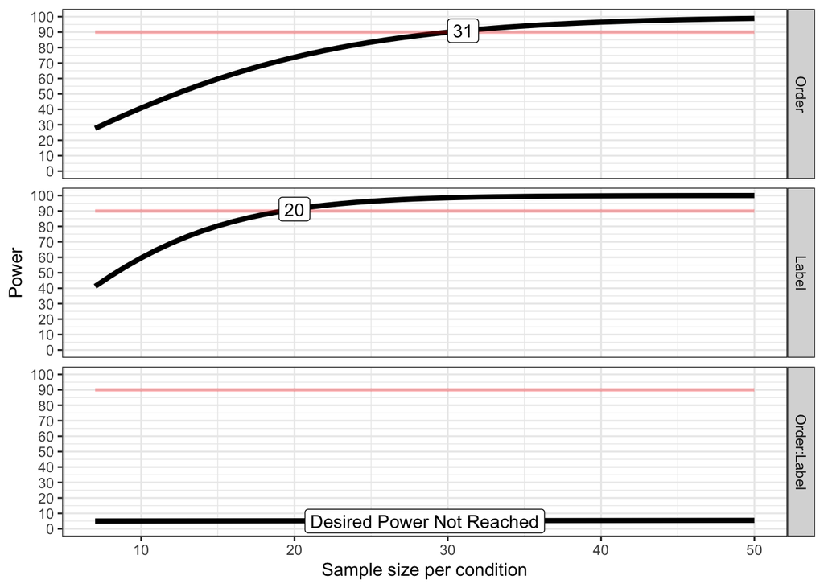

```
## Achieved Power and Sample Size for ANOVA-level effects
##      variable                     label  n achieved_power desired_power
## 1       Order    Desired Power Achieved 31          90.91            90
## 2       Label    Desired Power Achieved 20          91.18            90
## 3 Order:Label Desired Power Not Reached 50           5.44            90
```

```r
pw2 <- plot_power(dx2,
                  max_n = 50,
                  desired_power = 90,
                  plot = TRUE,
                  verbose = TRUE)
```

According to the simulation results, a minimum of 20 subjects was required to detect the difference between the self and stranger conditions. Given that our nonspatial working memory task differed from the task used by [Yin et al.](https://doi.org/10.1177/0956797618818483), we decided to recruit 50% more subjects, resulting in a total sample size of 30.

# 2 Stimuli & Tasks

Subjects completed an associative learning task followed by a working memory task.

1. Both tasks involved eight shapes selected from the Validated Circular Shape (VCS) space developed by [Li et al. (2019)](https://psycnet.apa.org/record/2019-58626-001), in which 360 shapes are arranged along a circular continuum to reflect gradual changes in shape similarity. In the VCS space, the eight shapes were evenly spaced at 45° intervals to maintain approximately equal perceptual dissimilarity.
2. The figure shows two successive example trials in the associative learning task. Each trial presented a red or blue shape with a superimposed social label—“당신” (the Korean word for “you”) or “타인” (the Korean word for “other”). Subjects were asked to judge whether the shape color matched the color associated with the referent of the label (self or other) prior to the experiment. The shape’s form was irrelevant to the task and was included solely to familiarize subjects with the shapes used in the later working memory task. Subjects responded using their right hand by pressing a button corresponding to either “match” or “mismatch.” We refer to this as the **label-matching response**.
3. Each trial of the working memory task presented a red shape, a blue shape, and a checkerboard pattern in sequence. In half of the trials, the red shape appeared first, and the blue shape appeared first in the other half. Subjects were required to briefly retain the samples’ colors and shapes in working memory. After a 1-second delay, a gray probe shape appeared on the screen, and subjects were asked to make a speeded and accurate judgment as to whether the probe matched either of the two previously presented samples. In 25% of the trials, the probe matched the first sample; in another 25%, it matched the second sample; and in the remaining 50%, it was a novel shape randomly drawn from the other six items in the shape set. Subjects responded using their left hand by pressing a button labeled “old” or “new.” We refer to this as the **shape-matching response**. On trials where the probe matched one of the two samples, a social label was superimposed on the probe immediately after the shape-matching response. Subjects were then asked to judge whether the color associated with the probed sample matched the color previously associated with the referent of the label (self or other). They responded using their right hand by pressing a button labeled “match” or “mismatch.” We refer to this as another **label-matching response**.

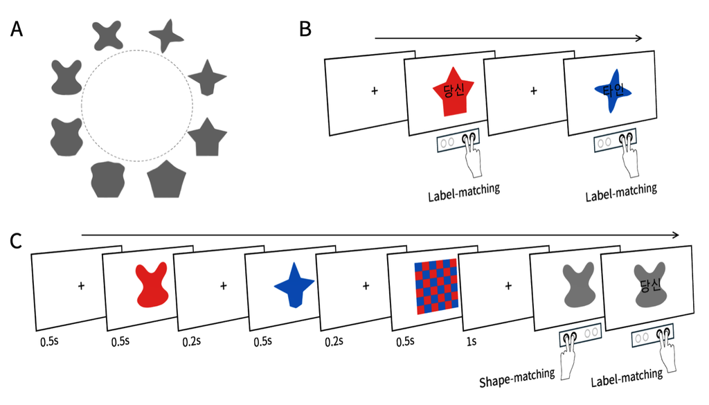

```r
ggdraw() + draw_image("fig/E1task.png")
```

# 3 Outlier Detection

We examined whether any of our subjects (*N* = 30) exhibited extreme performance that would warrant exclusion as outliers. Subjects made responses for label-matching in the associative learning task, and for both shape-matching and label-matching in the working memory task. For all three response types, we calculated each subject’s accuracy and mean response time (RT). Outlier subjects were identified using the boxplot method: a subject was classified as an outlier if their score on any of the six indices (three response types × accuracy and mean RT) exceeded Q3 + 3 × IQR or fell below Q1 – 3 × IQR.

Additionally, mean RTs were computed based only on correct responses, excluding values that deviated more than 2.5 standard deviations from the subject-specific mean.

In the raincloud plots below, each gray dot represents an individual subject’s performance across all trials. The red dashed line indicates the outlier cutoff at Q1 – 3 × IQR or Q3 + 3 × IQR, and the black dotted line marks Q1 – 1.5 × IQR or Q3 + 1.5 × IQR.

```r
# Associative Learning Task =============================
s <- read.csv("data/datSPE8VCS1LRN.csv", header = T) %>%
  mutate(SN = factor(SN),
         Matching = factor(Matching,
                           labels = c("Match", "Nonmatch"),
                           levels = c("Match", "Nonmatch")),
         Label = ifelse(Label == "Other", "Stranger", "Self"),
         Label = factor(Label,
                        labels = c("Self", "Stranger"),
                        levels = c("Self", "Stranger")))
str(s)
## 'data.frame':    4320 obs. of  6 variables:
##  $ SN      : Factor w/ 30 levels "1","2","3","4",..: 1 1 1 1 1 1 1 1 1 1 ...
##  $ Matching: Factor w/ 2 levels "Match","Nonmatch": 1 2 1 1 2 2 1 1 1 2 ...
##  $ Label   : Factor w/ 2 levels "Self","Stranger": 1 1 1 1 1 2 2 1 2 2 ...
##  $ Response: chr  "Match" "Nonmatch" "Match" "Nonmatch" ...
##  $ Correct : int  1 1 1 0 1 1 0 1 0 1 ...
##  $ RT      : num  4161 1185 1289 871 2027 ...
headTail(s)
##        SN Matching    Label Response Correct     RT
## 1       1    Match     Self    Match       1 4161.4
## 2       1 Nonmatch     Self Nonmatch       1 1185.3
## 3       1    Match     Self    Match       1 1288.9
## 4       1    Match     Self Nonmatch       0  870.6
## ...  <NA>     <NA>     <NA>     <NA>     ...    ...
## 4317   30 Nonmatch Stranger Nonmatch       1 1323.8
## 4318   30 Nonmatch     Self Nonmatch       1  993.9
## 4319   30 Nonmatch Stranger Nonmatch       1 1732.4
## 4320   30 Nonmatch     Self    Match       0  828.4

# label-matching accuracy
s.gc <- s %>%
  group_by(SN) %>%
  summarise(M = mean(Correct)) %>%
  ungroup()

s.gc %>% identify_outliers(M)
## # A tibble: 2 × 4
##   SN        M is.outlier is.extreme
##   <fct> <dbl> <lgl>      <lgl>
## 1 1     0.736 TRUE       TRUE
## 2 6     0.812 TRUE       FALSE

tmp <- s.gc %>%
  summarise(Outlier = quantile(M, prob = .25) - 1.5 * IQR(M),
            Extreme = quantile(M, prob = .25) - 3 * IQR(M))

Fo1 <- s.gc %>%
  single_raincloud_plot(.$M, 0.5, 1, 0.1, "Label-Matching Accuracy") +
  geom_hline(yintercept=tmp$Outlier, linetype="dotted") +
  geom_hline(yintercept=tmp$Extreme, linetype='dashed', color='red', linewidth=0.5)

# label-matching RT
range(s$RT[s$Correct==1])
## [1]  327.1 4712.6

st <- s %>%
  filter(Correct == 1) %>%
  group_by(SN) %>%
  nest() %>%
  mutate(lbound = map(data, ~mean(.$RT)-tOff*sd(.$RT)),
         ubound = map(data, ~mean(.$RT)+tOff*sd(.$RT))) %>%
  unnest(c(lbound, ubound)) %>%
  unnest(data) %>%
  mutate(Outlier = (RT < lbound)|(RT > ubound)) %>%
  filter(Outlier == FALSE) %>%
  ungroup() %>%
  select(SN, Matching, Label,  RT)

table(st$Matching, st$SN)
##
##             1  2  3  4  5  6  7  8  9 10 11 12 13 14 15 16 17 18 19 20 21 22 23
##   Match    39 68 68 69 71 59 66 67 67 69 69 65 69 70 71 63 69 66 64 69 71 67 70
##   Nonmatch 64 63 62 68 68 55 63 66 71 65 67 68 68 70 67 62 67 69 66 66 62 68 69
##
##            24 25 26 27 28 29 30
##   Match    66 66 71 70 68 69 61
##   Nonmatch 68 63 68 68 69 67 61
table(st$Label, st$SN)
##
##             1  2  3  4  5  6  7  8  9 10 11 12 13 14 15 16 17 18 19 20 21 22 23
##   Self     52 68 63 69 70 62 66 69 71 69 71 70 71 70 67 67 70 67 69 69 69 69 71
##   Stranger 51 63 67 68 69 52 63 64 67 65 65 63 66 70 71 58 66 68 61 66 64 66 68
##
##            24 25 26 27 28 29 30
##   Self     71 66 71 71 69 69 64
##   Stranger 63 63 68 67 68 67 58

range(st$RT)
## [1]  327.1 2955.4

tmp <- st %>%
  group_by(SN, Matching, Label) %>%
  summarise(n = n()) %>%
  ungroup()
range(tmp$n) # check min & max number of trials.
## [1] 19 36
tmp %>%
  unite("Cond", Matching:Label) %>%
  pivot_wider(id_cols = SN, names_from = Cond, values_from = n) %>%
  print(n = Inf) # relatively high accuracy. seems enough number of trials.
## # A tibble: 30 × 5
##    SN    Match_Self Match_Stranger Nonmatch_Self Nonmatch_Stranger
##    <fct>      <int>          <int>         <int>             <int>
##  1 1             20             19            32                32
##  2 2             36             32            32                31
##  3 3             34             34            29                33
##  4 4             36             33            33                35
##  5 5             36             35            34                34
##  6 6             32             27            30                25
##  7 7             36             30            30                33
##  8 8             35             32            34                32
##  9 9             36             31            35                36
## 10 10            36             33            33                32
## 11 11            36             33            35                32
## 12 12            35             30            35                33
## 13 13            36             33            35                33
## 14 14            36             34            34                36
## 15 15            35             36            32                35
## 16 16            36             27            31                31
## 17 17            35             34            35                32
## 18 18            33             33            34                35
## 19 19            35             29            34                32
## 20 20            35             34            34                32
## 21 21            36             35            33                29
## 22 22            36             31            33                35
## 23 23            36             34            35                34
## 24 24            36             30            35                33
## 25 25            35             31            31                32
## 26 26            36             35            35                33
## 27 27            36             34            35                33
## 28 28            35             33            34                35
## 29 29            35             34            34                33
## 30 30            34             27            30                31
```

```r
( pTrim1 <- 100*(sum(s$Correct) - nrow(st))/sum(s$Correct) ) # proportion of trimmed RTs
## [1] 2.382122

s.gt <- st %>%
  group_by(SN) %>%
  summarise(M = mean(RT)) %>%
  ungroup()

s.gt %>% identify_outliers(M)
## # A tibble: 1 × 4
##   SN        M is.outlier is.extreme
##   <fct> <dbl> <lgl>      <lgl>
## 1 10    1175. TRUE       FALSE

tmp <- s.gt %>%
  summarise(Outlier = quantile(M, prob = .75) + 1.5 * IQR(M),
            Extreme = quantile(M, prob = .75) + 3 * IQR(M))

Fo2 <- s.gt %>%
  single_raincloud_plot(.$M, 200, 1400, 200, "Label Matching RT (ms)") +
  geom_hline(yintercept=tmp$Outlier, linetype="dotted") +
  geom_hline(yintercept=tmp$Extreme, linetype='dashed', color='red', linewidth=0.5)


# Working Memory Task ==========================

# Shape-matching accuracy
d <- read.csv("data/datSPE8VCS1TST.csv", header = T) %>%
  mutate(SN = factor(SN),
         Person = ifelse(Person == "Other", "Stranger", "Self"),
         Person = factor(Person,
                         labels = c("Self", "Stranger"),
                         levels = c("Self", "Stranger")),
         Order = factor(Order),
         Change = factor(Change),
         Matching = factor(Matching),
         Label = ifelse(Label == "Other", "Stranger", "Self"),
         Label = factor(Label,
                        labels = c("Self", "Stranger"),
                        levels = c("Self", "Stranger")))
str(d)
## 'data.frame':    8639 obs. of  10 variables:
##  $ SN      : Factor w/ 30 levels "1","2","3","4",..: 1 1 1 1 1 1 1 1 1 1 ...
##  $ Screen  : chr  "probe" "label" "probe" "label" ...
##  $ Person  : Factor w/ 2 levels "Self","Stranger": 1 1 2 2 2 2 1 1 2 2 ...
##  $ Order   : Factor w/ 3 levels "","First","Second": 3 3 2 2 3 3 2 2 3 3 ...
##  $ Change  : Factor w/ 2 levels "Different","Same": 2 2 2 2 2 2 2 2 2 2 ...
##  $ Matching: Factor w/ 3 levels "","Match","Nonmatch": 3 3 2 2 2 2 2 2 2 2 ...
##  $ Label   : Factor w/ 2 levels "Self","Stranger": 2 2 2 2 2 2 1 1 2 2 ...
##  $ Response: chr  "Same" "Nonmatch" "Same" "Match" ...
##  $ Correct : int  1 1 1 1 1 1 1 1 1 1 ...
##  $ RT      : num  865 789 1071 781 1054 ...
headTail(d)
##        SN Screen   Person  Order    Change Matching    Label  Response Correct
## 1       1  probe     Self Second      Same Nonmatch Stranger      Same       1
## 2       1  label     Self Second      Same Nonmatch Stranger  Nonmatch       1
## 3       1  probe Stranger  First      Same    Match Stranger      Same       1
## 4       1  label Stranger  First      Same    Match Stranger     Match       1
## ...  <NA>   <NA>     <NA>   <NA>      <NA>     <NA>     <NA>      <NA>     ...
## 8636   30  label Stranger  First      Same Nonmatch     Self  Nonmatch       1
## 8637   30  probe     Self  First      Same Nonmatch Stranger      Same       1
## 8638   30  label     Self  First      Same Nonmatch Stranger  Nonmatch       1
## 8639   30  probe     <NA>        Different              <NA> Different       1
##          RT
## 1     865.2
## 2     789.3
## 3    1071.5
## 4       781
## ...     ...
## 8636  927.2
## 8637  765.4
## 8638  730.8
## 8639  595.6

# change trials: to be excluded from analysis
d.diff <- d %>% filter(Change == "Different") %>%
  droplevels() %>%
  select(!c(Screen, Person, Order, Change, Matching, Label))
table(d.diff$SN) # The last trial of Subject 12 was omitted for unknown reason.
##
##  1  2  3  4  5  6  7  8  9 10 11 12 13 14 15 16 17 18 19 20 21 22 23 24 25 26
## 96 96 96 96 96 96 96 96 96 96 96 95 96 96 96 96 96 96 96 96 96 96 96 96 96 96
## 27 28 29 30
## 96 96 96 96
table(d.diff$Response, d.diff$SN)
##
##              1  2  3  4  5  6  7  8  9 10 11 12 13 14 15 16 17 18 19 20 21 22
##   Different 88 89 82 93 91 75 89 83 84 73 88 85 91 86 83 81 86 80 87 82 93 90
##   Same       8  7 14  3  5 21  7 13 12 23  8 10  5 10 13 15 10 16  9 14  3  6
##
##             23 24 25 26 27 28 29 30
##   Different 85 86 79 94 88 87 91 87
##   Same      11 10 17  2  8  9  5  9
table(d.diff$Correct, d.diff$SN)
##
##      1  2  3  4  5  6  7  8  9 10 11 12 13 14 15 16 17 18 19 20 21 22 23 24 25
##   0  8  7 14  3  5 21  7 13 12 23  8 10  5 10 13 15 10 16  9 14  3  6 11 10 17
##   1 88 89 82 93 91 75 89 83 84 73 88 85 91 86 83 81 86 80 87 82 93 90 85 86 79
##
##     26 27 28 29 30
##   0  2  8  9  5  9
##   1 94 88 87 91 87

# no change trials.
d.same <- d %>% filter(Change == "Same", Screen == "probe") %>%
  droplevels() %>%
  select(!c(Screen, Change, Matching, Label)) %>%
  rename(Label = Person)
str(d.same)
## 'data.frame':    2880 obs. of  6 variables:
##  $ SN      : Factor w/ 30 levels "1","2","3","4",..: 1 1 1 1 1 1 1 1 1 1 ...
##  $ Label   : Factor w/ 2 levels "Self","Stranger": 1 2 2 1 2 1 1 1 1 2 ...
##  $ Order   : Factor w/ 2 levels "First","Second": 2 1 2 1 2 1 2 1 2 1 ...
##  $ Response: chr  "Same" "Same" "Same" "Same" ...
##  $ Correct : int  1 1 1 1 1 1 1 1 1 1 ...
##  $ RT      : num  865 1071 1054 846 1326 ...
table(d.same$SN)
##
##  1  2  3  4  5  6  7  8  9 10 11 12 13 14 15 16 17 18 19 20 21 22 23 24 25 26
## 96 96 96 96 96 96 96 96 96 96 96 96 96 96 96 96 96 96 96 96 96 96 96 96 96 96
## 27 28 29 30
## 96 96 96 96
table(d.same$Label, d.same$SN)
##
##             1  2  3  4  5  6  7  8  9 10 11 12 13 14 15 16 17 18 19 20 21 22 23
##   Self     48 48 48 48 48 48 48 48 48 48 48 48 48 48 48 48 48 48 48 48 48 48 48
##   Stranger 48 48 48 48 48 48 48 48 48 48 48 48 48 48 48 48 48 48 48 48 48 48 48
##
##            24 25 26 27 28 29 30
##   Self     48 48 48 48 48 48 48
##   Stranger 48 48 48 48 48 48 48
table(d.same$Order, d.same$SN)
##
##           1  2  3  4  5  6  7  8  9 10 11 12 13 14 15 16 17 18 19 20 21 22 23
##   First  48 48 48 48 48 48 48 48 48 48 48 48 48 48 48 48 48 48 48 48 48 48 48
##   Second 48 48 48 48 48 48 48 48 48 48 48 48 48 48 48 48 48 48 48 48 48 48 48
##
##          24 25 26 27 28 29 30
##   First  48 48 48 48 48 48 48
##   Second 48 48 48 48 48 48 48
table(d.same$Response, d.same$SN)
##
##              1  2  3  4  5  6  7  8  9 10 11 12 13 14 15 16 17 18 19 20 21 22
##   Different  6  1 16  1  3 17 14 25  8 22  7 10  1  6  6  4 20 12 13  3  9 11
##   Same      90 95 80 95 93 79 82 71 88 74 89 86 95 90 90 92 76 84 83 93 87 85
##
##             23 24 25 26 27 28 29 30
##   Different 16 10 23  4  5  9  3 14
##   Same      80 86 73 92 91 87 93 82
table(d.same$Correct, d.same$SN)
##
##      1  2  3  4  5  6  7  8  9 10 11 12 13 14 15 16 17 18 19 20 21 22 23 24 25
##   0  6  1 16  1  3 17 14 25  8 22  7 10  1  6  6  4 20 12 13  3  9 11 16 10 23
##   1 90 95 80 95 93 79 82 71 88 74 89 86 95 90 90 92 76 84 83 93 87 85 80 86 73
##
##     26 27 28 29 30
##   0  4  5  9  3 14
##   1 92 91 87 93 82
```

```r
# Outlier detection by signal detection thoeretical d'
d.sdt <- d %>%
  filter(Screen == "probe") %>%
  group_by(SN, Change) %>%
  summarise(rate = mean(Correct)) %>%
  ungroup() %>%
  pivot_wider(id_cols = SN, names_from = Change, values_from = rate) %>%
  rename(Hit = Different, FA = Same) %>%
  mutate(FA = 1 - FA,
         hitEDGE = (Hit==1),
         faEDGE = (FA==0)) %>%
  mutate(Dprime = qnorm(Hit) - qnorm(FA))

print(d.sdt, n = Inf)
## # A tibble: 30 × 6
##    SN      Hit     FA hitEDGE faEDGE Dprime
##    <fct> <dbl>  <dbl> <lgl>   <lgl>   <dbl>
##  1 1     0.917 0.0625 FALSE   FALSE    2.92
##  2 2     0.927 0.0104 FALSE   FALSE    3.77
##  3 3     0.854 0.167  FALSE   FALSE    2.02
##  4 4     0.969 0.0104 FALSE   FALSE    4.17
##  5 5     0.948 0.0312 FALSE   FALSE    3.49
##  6 6     0.781 0.177  FALSE   FALSE    1.70
##  7 7     0.927 0.146  FALSE   FALSE    2.51
##  8 8     0.865 0.260  FALSE   FALSE    1.74
##  9 9     0.875 0.0833 FALSE   FALSE    2.53
## 10 10    0.760 0.229  FALSE   FALSE    1.45
## 11 11    0.917 0.0729 FALSE   FALSE    2.84
## 12 12    0.895 0.104  FALSE   FALSE    2.51
## 13 13    0.948 0.0104 FALSE   FALSE    3.94
## 14 14    0.896 0.0625 FALSE   FALSE    2.79
## 15 15    0.865 0.0625 FALSE   FALSE    2.64
## 16 16    0.844 0.0417 FALSE   FALSE    2.74
## 17 17    0.896 0.208  FALSE   FALSE    2.07
## 18 18    0.833 0.125  FALSE   FALSE    2.12
## 19 19    0.906 0.135  FALSE   FALSE    2.42
## 20 20    0.854 0.0312 FALSE   FALSE    2.92
## 21 21    0.969 0.0938 FALSE   FALSE    3.18
## 22 22    0.938 0.115  FALSE   FALSE    2.74
## 23 23    0.885 0.167  FALSE   FALSE    2.17
## 24 24    0.896 0.104  FALSE   FALSE    2.52
## 25 25    0.823 0.240  FALSE   FALSE    1.63
## 26 26    0.979 0.0417 FALSE   FALSE    3.77
## 27 27    0.917 0.0521 FALSE   FALSE    3.01
## 28 28    0.906 0.0938 FALSE   FALSE    2.64
## 29 29    0.948 0.0312 FALSE   FALSE    3.49
## 30 30    0.906 0.146  FALSE   FALSE    2.37

d.sdt %>% identify_outliers(Dprime) # Subject 4 was good
## # A tibble: 1 × 8
##   SN      Hit     FA hitEDGE faEDGE Dprime is.outlier is.extreme
##   <fct> <dbl>  <dbl> <lgl>   <lgl>   <dbl> <lgl>      <lgl>
## 1 4     0.969 0.0104 FALSE   FALSE    4.17 TRUE       FALSE

# tmp <- d.sdt %>%
#   summarise(Lfence = quantile(Dprime, prob = .25) - 1.5 * IQR(Dprime),
#             Ufence = quantile(Dprime, prob = .75) + 1.5 * IQR(Dprime))
#
# d.sdt %>%
#   single_raincloud_plot(.$Dprime, 0, 5, 1, expression(paste(italic(d), "'"))) +
#   geom_hline(yintercept=tmp$Lfence, linetype="dotted") +
#   geom_hline(yintercept=tmp$Ufence, linetype="dotted")

# Outlier detection by accuracy
d.gc <- d %>%
  filter(Screen == "probe") %>%
  group_by(SN) %>%
  summarise(M = mean(Correct)) %>%
  ungroup()

d.gc %>% identify_outliers(M)
## [1] SN         M          is.outlier is.extreme
## <0 rows> (or 0-length row.names)

tmp <- d.gc %>%
  summarise(Outlier = quantile(M, prob = .25) - 1.5 * IQR(M),
            Extreme = quantile(M, prob = .25) - 3 * IQR(M))

Fo3 <- d.gc %>%
  single_raincloud_plot(.$M, 0.5, 1, 0.1, "WM Shape-Matching Accuracy") +
  geom_hline(yintercept=tmp$Outlier, linetype="dotted") +
  geom_hline(yintercept=tmp$Extreme, linetype='dashed', color='red', linewidth=0.5)

# Shape-matching RT
range(d.same$RT[d.same$Correct==1])
## [1]   364.0 15223.3

dst <- d.same %>%
  filter(Correct == 1) %>%
  group_by(SN) %>%
  nest() %>%
  mutate(lbound = map(data, ~mean(.$RT)-tOff*sd(.$RT)),
         ubound = map(data, ~mean(.$RT)+tOff*sd(.$RT))) %>%
  unnest(c(lbound, ubound)) %>%
  unnest(data) %>%
  mutate(Outlier = (RT < lbound)|(RT > ubound)) %>%
  filter(Outlier == FALSE) %>%
  ungroup %>%
  select(SN, Label, Order, RT)

table(dst$Label, dst$SN)
##
##             1  2  3  4  5  6  7  8  9 10 11 12 13 14 15 16 17 18 19 20 21 22 23
##   Self     46 48 40 47 46 41 40 33 44 34 43 41 47 43 43 47 39 41 41 46 44 46 41
##   Stranger 44 45 38 46 43 37 41 36 43 36 44 43 46 46 46 43 35 42 40 45 41 37 37
##
##            24 25 26 27 28 29 30
##   Self     45 37 45 45 40 44 41
##   Stranger 37 32 45 43 44 47 39
table(dst$Order, dst$SN)
##
##           1  2  3  4  5  6  7  8  9 10 11 12 13 14 15 16 17 18 19 20 21 22 23
##   First  47 46 41 48 43 38 46 37 47 37 46 45 46 43 44 44 40 41 43 47 45 43 41
##   Second 43 47 37 45 46 40 35 32 40 33 41 39 47 46 45 46 34 42 38 44 40 40 37
##
##          24 25 26 27 28 29 30
##   First  38 44 43 47 41 44 39
##   Second 44 25 47 41 43 47 41

range(st$RT)
## [1]  327.1 2955.4

tmp <- dst %>%
  group_by(SN, Order, Label) %>%
  summarise(n = n()) %>%
  ungroup()
range(tmp$n) # check min & max number of trials
## [1] 11 24
tmp %>%
  unite("Cond", Order:Label) %>%
  pivot_wider(id_cols = SN, names_from = Cond, values_from = n) %>%
  print(n = Inf) # SN 25 had only 11 trials.
## # A tibble: 30 × 5
##    SN    First_Self First_Stranger Second_Self Second_Stranger
##    <fct>      <int>          <int>       <int>           <int>
##  1 1             24             23          22              21
##  2 2             24             22          24              23
##  3 3             20             21          20              17
##  4 4             24             24          23              22
##  5 5             22             21          24              22
##  6 6             21             17          20              20
##  7 7             23             23          17              18
##  8 8             16             21          17              15
##  9 9             23             24          21              19
## 10 10            17             20          17              16
## 11 11            22             24          21              20
## 12 12            21             24          20              19
## 13 13            24             22          23              24
## 14 14            21             22          22              24
## 15 15            22             22          21              24
## 16 16            23             21          24              22
## 17 17            20             20          19              15
## 18 18            21             20          20              22
## 19 19            22             21          19              19
## 20 20            23             24          23              21
## 21 21            23             22          21              19
## 22 22            24             19          22              18
## 23 23            21             20          20              17
## 24 24            22             16          23              21
## 25 25            23             21          14              11
## 26 26            22             21          23              24
## 27 27            23             24          22              19
## 28 28            20             21          20              23
## 29 29            21             23          23              24
## 30 30            19             20          22              19
```

```r
( pTrim2 <- 100*(sum(d.same$Correct) - nrow(dst))/sum(d.same$Correct) ) # proportion of trimmed RTs
## [1] 2.40217

# global RT
d.gt <- dst %>%
  group_by(SN) %>%
  summarise(M = mean(RT)) %>%
  ungroup()

tmp <- d.gt %>%
  summarise(OutlierL = quantile(M, prob = .25) - 1.5 * IQR(M),
            OutlierU = quantile(M, prob = .75) + 1.5 * IQR(M))

Fo4 <- d.gt %>%
  single_raincloud_plot(.$M, 200, 1400, 200, "WM Shape-Matching RT (ms)") +
  geom_hline(yintercept=tmp$OutlierL, linetype="dotted") +
  geom_hline(yintercept=tmp$OutlierU, linetype="dotted")

#  Lable-matching accuracy
d.spe <- d %>%
  filter(Screen == "label") %>% # all "label' = "Same"
  droplevels() %>%
  select(!c(Screen, Person, Order, Change))
str(d.spe)
## 'data.frame':    2880 obs. of  6 variables:
##  $ SN      : Factor w/ 30 levels "1","2","3","4",..: 1 1 1 1 1 1 1 1 1 1 ...
##  $ Matching: Factor w/ 2 levels "Match","Nonmatch": 2 1 1 1 1 1 2 2 1 1 ...
##  $ Label   : Factor w/ 2 levels "Self","Stranger": 2 2 2 1 2 1 2 2 1 2 ...
##  $ Response: chr  "Nonmatch" "Match" "Match" "Match" ...
##  $ Correct : int  1 1 1 1 1 1 1 1 1 1 ...
##  $ RT      : num  789 781 695 620 961 ...
table(d.spe$Matching, d.spe$SN)
##
##             1  2  3  4  5  6  7  8  9 10 11 12 13 14 15 16 17 18 19 20 21 22 23
##   Match    48 48 48 48 48 48 48 48 48 48 48 48 48 48 48 48 48 48 48 48 48 48 48
##   Nonmatch 48 48 48 48 48 48 48 48 48 48 48 48 48 48 48 48 48 48 48 48 48 48 48
##
##            24 25 26 27 28 29 30
##   Match    48 48 48 48 48 48 48
##   Nonmatch 48 48 48 48 48 48 48
table(d.spe$Label, d.spe$SN)
##
##             1  2  3  4  5  6  7  8  9 10 11 12 13 14 15 16 17 18 19 20 21 22 23
##   Self     48 48 48 48 48 48 48 48 48 48 48 48 48 48 48 48 48 48 48 48 48 48 48
##   Stranger 48 48 48 48 48 48 48 48 48 48 48 48 48 48 48 48 48 48 48 48 48 48 48
##
##            24 25 26 27 28 29 30
##   Self     48 48 48 48 48 48 48
##   Stranger 48 48 48 48 48 48 48
table(d.spe$Response, d.spe$SN)
##
##             1  2  3  4  5  6  7  8  9 10 11 12 13 14 15 16 17 18 19 20 21 22 23
##   Match    54 48 53 49 49 61 50 58 40 52 43 46 43 48 47 42 51 51 50 42 47 51 47
##   Nonmatch 42 48 43 47 47 35 46 38 56 44 53 50 53 48 49 54 45 45 46 54 49 45 49
##
##            24 25 26 27 28 29 30
##   Match    48 58 48 46 45 51 49
##   Nonmatch 48 38 48 50 51 45 47
table(d.spe$Correct, d.spe$SN)
##
##      1  2  3  4  5  6  7  8  9 10 11 12 13 14 15 16 17 18 19 20 21 22 23 24 25
##   0 10  2  9  3  1 33 10 24  8 30  5 20  5  6 13 12 11  9 22 16  3  5 19  6 24
##   1 86 94 87 93 95 63 86 72 88 66 91 76 91 90 83 84 85 87 74 80 93 91 77 90 72
##
##     26 27 28 29 30
##   0  8 10 13  9 11
##   1 88 86 83 87 85

d.gs <- d.spe %>%
  group_by(SN) %>%
  summarise(M = mean(Correct)) %>%
  ungroup()

d.gs %>% identify_outliers(M)
## # A tibble: 2 × 4
##   SN        M is.outlier is.extreme
##   <fct> <dbl> <lgl>      <lgl>
## 1 6     0.656 TRUE       FALSE
## 2 10    0.688 TRUE       FALSE

tmp <- d.gs %>%
  summarise(Outlier = quantile(M, prob = .25) - 1.5 * IQR(M),
            Extreme = quantile(M, prob = .25) - 3 * IQR(M))

Fo5 <- d.gs %>%
  single_raincloud_plot(.$M, 0.5, 1, 0.1, "WM Label-Matching Accuracy") +
  geom_hline(yintercept=tmp$Outlier, linetype="dotted") +
  geom_hline(yintercept=tmp$Extreme, linetype='dashed', color='red', linewidth=0.5)


# Label-matching RT
range(d.spe$RT[d.spe$Correct==1])
## [1]  264.2 8908.2

dpt <- d.spe %>%
  filter(Correct == 1) %>%
  group_by(SN) %>%
  nest() %>%
  mutate(lbound = map(data, ~mean(.$RT)-tOff*sd(.$RT)),
         ubound = map(data, ~mean(.$RT)+tOff*sd(.$RT))) %>%
  unnest(c(lbound, ubound)) %>%
  unnest(data) %>%
  mutate(Outlier = (RT < lbound)|(RT > ubound)) %>%
  filter(Outlier == FALSE) %>%
  ungroup %>%
  select(SN, Matching, Label,  RT)

table(dpt$Matching, dpt$SN)
##
##             1  2  3  4  5  6  7  8  9 10 11 12 13 14 15 16 17 18 19 20 21 22 23
##   Match    44 45 43 47 47 38 42 40 38 35 42 35 43 42 39 38 44 44 38 36 46 45 37
##   Nonmatch 38 46 41 43 45 23 42 30 44 29 46 38 47 44 40 45 37 42 33 42 44 44 38
##
##            24 25 26 27 28 29 30
##   Match    44 40 44 41 39 43 42
##   Nonmatch 44 31 42 43 41 41 41
table(dpt$Label, dpt$SN)
##
##             1  2  3  4  5  6  7  8  9 10 11 12 13 14 15 16 17 18 19 20 21 22 23
##   Self     42 47 44 43 46 32 43 32 40 36 42 41 45 44 40 42 41 42 40 40 45 46 40
##   Stranger 40 44 40 47 46 29 41 38 42 28 46 32 45 42 39 41 40 44 31 38 45 43 35
##
##            24 25 26 27 28 29 30
##   Self     45 38 43 42 40 41 41
##   Stranger 43 33 43 42 40 43 42

range(dpt$RT)
## [1]  264.2 3787.5

tmp <- dpt %>%
  group_by(SN, Matching, Label) %>%
  summarise(n = n()) %>%
  ungroup()
range(tmp$n)
## [1] 10 24
tmp %>%
  unite("Cond", Matching:Label) %>%
  pivot_wider(id_cols = SN, names_from = Cond, values_from = n) %>%
  print(n = Inf)
## # A tibble: 30 × 5
##    SN    Match_Self Match_Stranger Nonmatch_Self Nonmatch_Stranger
##    <fct>      <int>          <int>         <int>             <int>
##  1 1             23             21            19                19
##  2 2             23             22            24                22
##  3 3             23             20            21                20
##  4 4             23             24            20                23
##  5 5             24             23            22                23
##  6 6             19             19            13                10
##  7 7             22             20            21                21
##  8 8             17             23            15                15
##  9 9             19             19            21                23
## 10 10            18             17            18                11
## 11 11            20             22            22                24
## 12 12            18             17            23                15
## 13 13            22             21            23                24
## 14 14            22             20            22                22
## 15 15            18             21            22                18
## 16 16            20             18            22                23
## 17 17            23             21            18                19
## 18 18            22             22            20                22
## 19 19            21             17            19                14
## 20 20            17             19            23                19
## 21 21            22             24            23                21
## 22 22            24             21            22                22
## 23 23            19             18            21                17
## 24 24            23             21            22                22
## 25 25            20             20            18                13
## 26 26            22             22            21                21
## 27 27            20             21            22                21
## 28 28            19             20            21                20
## 29 29            20             23            21                20
## 30 30            21             21            20                21
```

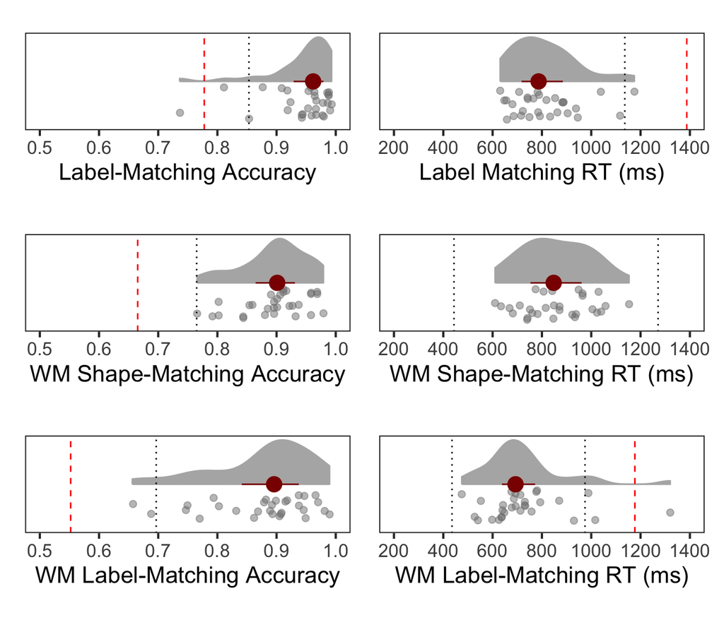

```r
( pTrim3 <- 100*(sum(d.spe$Correct) - nrow(dpt))/sum(d.spe$Correct) ) # proportion of trimmed RTs
## [1] 3.091558

dspe.gt <- dpt %>%
  group_by(SN) %>%
  summarise(M = mean(RT)) %>%
  ungroup()

dspe.gt %>% identify_outliers(M)
## # A tibble: 3 × 4
##   SN        M is.outlier is.extreme
##   <fct> <dbl> <lgl>      <lgl>
## 1 10    1016. TRUE       FALSE
## 2 28     989. TRUE       FALSE
## 3 30    1320. TRUE       TRUE

tmp <- dspe.gt %>%
  summarise(OutlierL = quantile(M, prob = .25) - 1.5 * IQR(M),
            OutlierU = quantile(M, prob = .75) + 1.5 * IQR(M),
            Extreme = quantile(M, prob = .75) + 3 * IQR(M))

Fo6 <- dspe.gt %>%
  single_raincloud_plot(.$M, 200, 1400, 200, "WM Label-Matching RT (ms)") +
  geom_hline(yintercept=tmp$OutlierL, linetype="dotted") +
  geom_hline(yintercept=tmp$OutlierU, linetype="dotted") +
  geom_hline(yintercept=tmp$Extreme, linetype='dashed', color='red', linewidth=0.5)

(Fo1 | Fo2) / (Fo3 | Fo4) / (Fo5 | Fo6)
```

- Label-matching in the associative learning task
  - One subject (#1) showed outlier-level low accuracy.
  - No subjects were excluded based on mean RT, and 2.38% of RTs were removed as extreme values.
- Shape-matching response in the working memory task
  - No subjects were identified as outliers based on accuracy, and this result held when d′ was used instead of accuracy.
  - The key dependent measure was RT on correct **shape-probe-match trials**, referring to trials where the probe matched one of the two sample shapes in working memory ([Yin et al.](https://doi.org/10.1177/0956797618818483)). No subjects were excluded based on mean RTs, and 2.4% of RTs were removed as extreme values.
- Label-matching in the working memory task
  - No subjects were identified as outliers based on accuracy.
  - One subject (#30) was classified as an outlier due to a slow mean response time. In the computation of mean RTs, 3.09% of values were excluded as extreme.

```r
excluded <- c(1, 30)

s <- rm_subject(s, excluded)
## 2 removed & 28 left
st <- rm_subject(st, excluded)
## 2 removed & 28 left
d.same <- rm_subject(d.same, excluded)
## 2 removed & 28 left
dst <- rm_subject(dst, excluded)
## 2 removed & 28 left
d.spe <- rm_subject(d.spe, excluded)
## 2 removed & 28 left
dpt <- rm_subject(dpt, excluded)
## 2 removed & 28 left
```

In summary, one subject with low label-matching accuracy in the associative learning task and another with markedly slow label-matching RT in the working memory task were classified as outliers and excluded from further analyses. Importantly, the statistical conclusions were unchanged when these subjects were retained.

# 4 Associative Learning Task

## 4.1 Label-Matching Accuracy

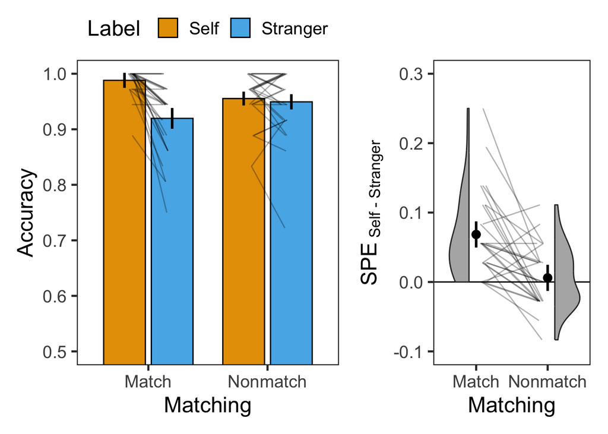

```r
s.acc <- s %>%
  group_by(SN, Matching, Label) %>%
  summarise(Accuracy = mean(Correct)) %>%
  ungroup()

plotMatchLabel(s.acc, "Accuracy", 0.5, 1, .1, FALSE, -.1, .3, .1)
```

```r
# Descriptive
s.acc %>% group_by(Matching, Label) %>%
  get_summary_stats(Accuracy, show = c("mean", "sd")) %>%
  kable(digits = 2, format = "simple", caption = "Descriptive summary")
```

Descriptive summary

| Matching | Label | variable | n | mean | sd |
| --- | --- | --- | --- | --- | --- |
| Match | Self | Accuracy | 28 | 0.99 | 0.02 |
| Match | Stranger | Accuracy | 28 | 0.92 | 0.06 |
| Nonmatch | Self | Accuracy | 28 | 0.96 | 0.05 |
| Nonmatch | Stranger | Accuracy | 28 | 0.95 | 0.06 |

```r
# BF
( bf.sAcc <- anovaBF(Accuracy ~ Matching*Label + SN, data = as.data.frame(s.acc),
                     whichRandom = "SN", iterations = nIter, progress = FALSE) )
## Bayes factor analysis
## --------------
## [1] Matching + SN                          : 0.2020331 ±0.35%
## [2] Label + SN                             : 1835.635  ±0.7%
## [3] Matching + Label + SN                  : 376.8199  ±2.13%
## [4] Matching + Label + Matching:Label + SN : 173567.8  ±0.63%
##
## Against denominator:
##   Accuracy ~ SN
## ---
## Bayes factor type: BFlinearModel, JZS
# plot(bf.sAcc)

# ANOVA
cbind(
  anova_test(
    data = s.acc, dv = Accuracy, wid = SN,
    within = c(Matching, Label),
    effect.size = "pes") %>%
    get_anova_table(),
  tibble(BF10 = c( exp((bf.sAcc[3]/bf.sAcc[2])@bayesFactor$bf), # Matching
                   exp((bf.sAcc[3]/bf.sAcc[1])@bayesFactor$bf), # Label
                   exp((bf.sAcc[4]/bf.sAcc[3])@bayesFactor$bf) ), # Matching x Label
         BF01 = c( exp((bf.sAcc[2]/bf.sAcc[3])@bayesFactor$bf),
                   exp((bf.sAcc[1]/bf.sAcc[3])@bayesFactor$bf),
                   exp((bf.sAcc[3]/bf.sAcc[4])@bayesFactor$bf) ))) %>%
  kable(digits = c(0,0,0,3,5,0,3,3,3), format = "simple", caption = "ANOVA")
```

ANOVA

| Effect | DFn | DFd | F | p | p<.05 | pes | BF10 | BF01 |
| --- | --- | --- | --- | --- | --- | --- | --- | --- |
| Matching | 1 | 27 | 0.042 | 0.83900 |  | 0.002 | 0.205 | 4.871 |
| Label | 1 | 27 | 22.404 | 0.00006 | * | 0.453 | 1865.139 | 0.001 |
| Matching:Label | 1 | 27 | 23.160 | 0.00005 | * | 0.462 | 460.612 | 0.002 |

```r
# Post-hoc
dgT <- 3
dgP <- 6
dgM <- 3
dgC <- 3
dgD <- 3
cbind(s.acc %>%
        group_by(Matching) %>%
        t_test(Accuracy ~ Label, ref.group = "Self",
               paired = TRUE, detailed = TRUE) %>%
        adjust_pvalue(method = "bonferroni") %>%
        add_significance("p.adj") %>%
        unite("Comparison", group1:group2, sep = " > ") %>%
        mutate("95% CI" = paste0("[", round(conf.low, digits = dgC), ", ",
                                 round(conf.high, digits = dgC), "]")) %>%
        rename('T' = statistic, M = estimate) %>%
        select(Matching, Comparison, 'T', df, p, p.adj, p.adj.signif,
               M, '95% CI'),
      s.acc %>%
        group_by(Matching) %>%
        cohens_d(Accuracy ~ Label, paired = TRUE, ref.group = "Self") %>%
        select("effsize", "magnitude") %>%
        rename("Cohen's d" = effsize)) %>%
  kable(digits = c(0,0,dgT,0,dgP,dgP,0,dgM,0,dgD,0),
        format = "simple", caption = "T-Test, Bonferroni Corrected")
```

T-Test, Bonferroni Corrected

| Matching | Comparison | T | df | p | p.adj | p.adj.signif | M | 95% CI | Cohen’s d | magnitude |
| --- | --- | --- | --- | --- | --- | --- | --- | --- | --- | --- |
| Match | Self > Stranger | 5.832 | 27 | 0.000003 | 0.000007 | **** | 0.068 | [0.044, 0.093] | 1.102 | large |
| Nonmatch | Self > Stranger | 0.711 | 27 | 0.483000 | 0.966000 | ns | 0.006 | [-0.011, 0.023] | 0.134 | negligible |

## 4.2 Label-Matching RT

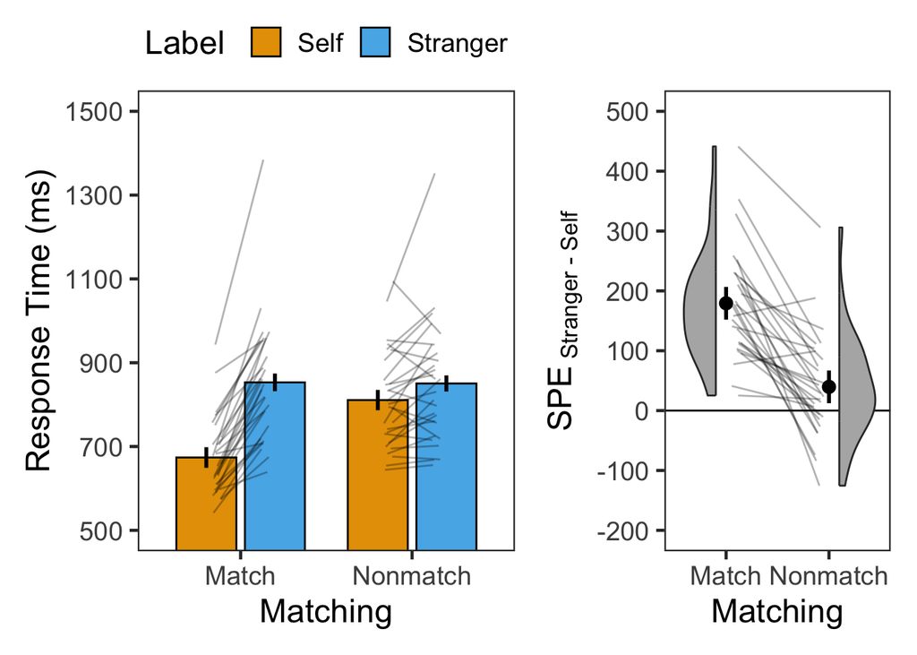

```r
s.rt <- st %>%
  group_by(SN, Matching, Label) %>%
  summarise(RT = mean(RT)) %>%
  ungroup()

plotMatchLabel(s.rt, "Response Time (ms)", 500, 1500, 200,
               TRUE, -200, 500, 100)
```

```r
# Descriptive
s.rt %>% group_by(Matching, Label) %>%
  get_summary_stats(RT, show = c("mean", "sd")) %>%
  kable(digits = 0, format = "simple", caption = "Descriptive summary")
```

Descriptive summary

| Matching | Label | variable | n | mean | sd |
| --- | --- | --- | --- | --- | --- |
| Match | Self | RT | 28 | 674 | 93 |
| Match | Stranger | RT | 28 | 853 | 149 |
| Nonmatch | Self | RT | 28 | 811 | 116 |
| Nonmatch | Stranger | RT | 28 | 850 | 147 |

```r
# BF
( bf.sRT <- anovaBF(RT ~ Matching*Label + SN, data = as.data.frame(s.rt),
                    whichRandom = "SN", iterations = nIter, progress = FALSE) )
## Bayes factor analysis
## --------------
## [1] Matching + SN                          : 77.65403          ±0.41%
## [2] Label + SN                             : 32084969          ±0.35%
## [3] Matching + Label + SN                  : 158872277832      ±0.61%
## [4] Matching + Label + Matching:Label + SN : 96469509162155104 ±1.08%
##
## Against denominator:
##   RT ~ SN
## ---
## Bayes factor type: BFlinearModel, JZS
# plot(bf.sRT)

# ANOVA
cbind(
  anova_test(
    data = s.rt, dv = RT, wid = SN,
    within = c(Matching, Label),
    effect.size = "pes") %>%
    get_anova_table() ,
  tibble(BF10 = c( exp((bf.sRT[3]/bf.sRT[2])@bayesFactor$bf),
                   exp((bf.sRT[3]/bf.sRT[1])@bayesFactor$bf),
                   exp((bf.sRT[4]/bf.sRT[3])@bayesFactor$bf) ),
         BF01 = c( exp((bf.sRT[2]/bf.sRT[3])@bayesFactor$bf),
                   exp((bf.sRT[1]/bf.sRT[3])@bayesFactor$bf),
                   exp((bf.sRT[3]/bf.sRT[4])@bayesFactor$bf) ))) %>%
  kable(digits = c(0,0,0,3,9,0,3,3,3), format = "simple", caption = "ANOVA")
```

ANOVA

| Effect | DFn | DFd | F | p | p<.05 | pes | BF10 | BF01 |
| --- | --- | --- | --- | --- | --- | --- | --- | --- |
| Matching | 1 | 27 | 67.373 | 0.000000008 | * | 0.714 | 4951.611 | 0 |
| Label | 1 | 27 | 59.443 | 0.000000027 | * | 0.688 | 2045898660.836 | 0 |
| Matching:Label | 1 | 27 | 54.859 | 0.000000057 | * | 0.670 | 607214.238 | 0 |

```r
# Post-hoc
dgT <- 3
dgP <- 11
dgM <- 0
dgC <- 0
dgD <- 3
cbind(s.rt %>%
        group_by(Matching) %>%
        t_test(RT ~ Label, ref.group = "Stranger",
               paired = TRUE, detailed = TRUE) %>%
        adjust_pvalue(method = "bonferroni") %>%
        add_significance("p.adj") %>%
        unite("Comparison", group1:group2, sep = " > ") %>%
        mutate("95% CI" = paste0("[", round(conf.low, digits = dgC), ", ",
                                 round(conf.high, digits = dgC), "]")) %>%
        rename('T' = statistic, M = estimate) %>%
        select(Matching, Comparison, 'T', df, p, p.adj, p.adj.signif,
               M, '95% CI'),
      s.rt %>%
        group_by(Matching) %>%
        cohens_d(RT ~ Label, paired = TRUE, ref.group = "Stranger") %>%
        select("effsize", "magnitude") %>%
        rename("Cohen's d" = effsize)) %>%
  kable(digits = c(0,0,dgT,0,dgP,dgP,0,dgM,0,dgD,0),
        format = "simple", caption = "T-Test, Bonferroni Corrected")
```

T-Test, Bonferroni Corrected

| Matching | Comparison | T | df | p | p.adj | p.adj.signif | M | 95% CI | Cohen’s d | magnitude |
| --- | --- | --- | --- | --- | --- | --- | --- | --- | --- | --- |
| Match | Stranger > Self | 10.238 | 27 | 0.00000000009 | 0.00000000017 | **** | 179 | [143, 215] | 1.935 | large |
| Nonmatch | Stranger > Self | 2.394 | 27 | 0.02390000000 | 0.04780000000 | * | 40 | [6, 74] | 0.452 | small |

# 5 Working Memory Task

## 5.1 Shape-Matching Accuracy

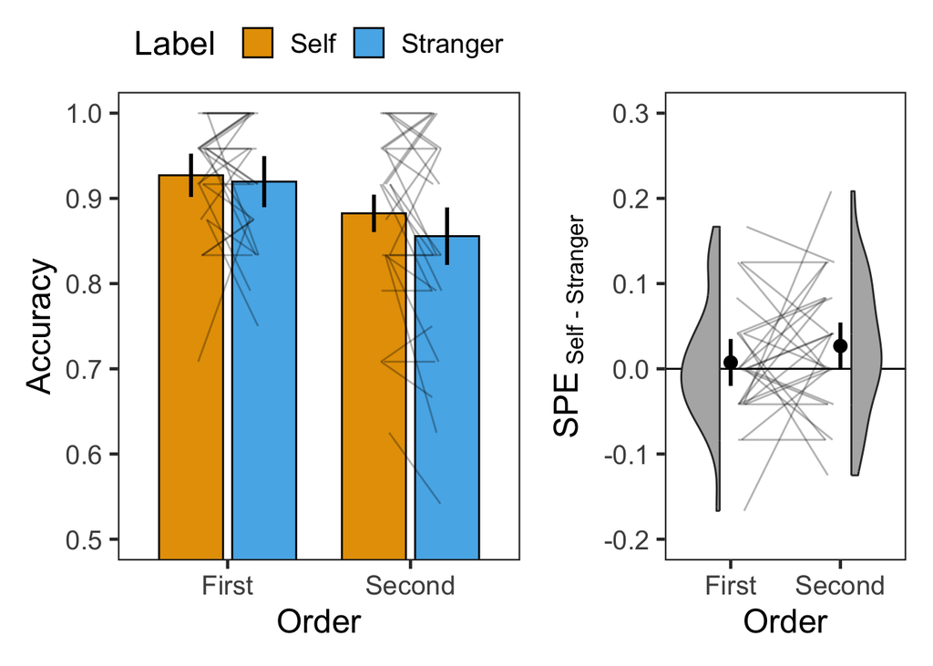

```r
d.same.acc <- d.same %>%
  group_by(SN, Order, Label) %>%
  summarise(Accuracy = mean(Correct)) %>%
  ungroup()

plotOrderLabel(d.same.acc, "Accuracy", 0.5, 1, .1, FALSE, -.2, .3, .1)
```

```r
# Descriptive
d.same.acc %>% group_by(Order, Label) %>%
  get_summary_stats(Accuracy, show = c("mean", "sd")) %>%
  kable(digits = 2, format = "simple", caption = "Descriptive summary")
```

Descriptive summary

| Order | Label | variable | n | mean | sd |
| --- | --- | --- | --- | --- | --- |
| First | Self | Accuracy | 28 | 0.93 | 0.07 |
| First | Stranger | Accuracy | 28 | 0.92 | 0.07 |
| Second | Self | Accuracy | 28 | 0.88 | 0.10 |
| Second | Stranger | Accuracy | 28 | 0.86 | 0.13 |

```r
# BF
( bf.dAcc <- anovaBF(Accuracy ~ Order*Label + SN, data = as.data.frame(d.same.acc),
                     whichRandom = "SN", iterations = nIter, progress = FALSE) )
## Bayes factor analysis
## --------------
## [1] Order + SN                       : 149.9328  ±0.16%
## [2] Label + SN                       : 0.3634671 ±0.31%
## [3] Order + Label + SN               : 60.54297  ±0.4%
## [4] Order + Label + Order:Label + SN : 19.97899  ±0.82%
##
## Against denominator:
##   Accuracy ~ SN
## ---
## Bayes factor type: BFlinearModel, JZS

# ANOVA
cbind(
  anova_test(
    data = d.same.acc, dv = Accuracy, wid = SN,
    within = c(Order, Label),
    effect.size = "pes") %>%
    get_anova_table() ,
  tibble(BF10 = c( exp((bf.dAcc[3]/bf.dAcc[2])@bayesFactor$bf),
                   exp((bf.dAcc[3]/bf.dAcc[1])@bayesFactor$bf),
                   exp((bf.dAcc[4]/bf.dAcc[3])@bayesFactor$bf) ),
         BF01 = c( exp((bf.dAcc[2]/bf.dAcc[3])@bayesFactor$bf),
                   exp((bf.dAcc[1]/bf.dAcc[3])@bayesFactor$bf),
                   exp((bf.dAcc[3]/bf.dAcc[4])@bayesFactor$bf) ))) %>%
  kable(digits = c(0,0,0,3,3,0,3,3,3), format = "simple", caption = "ANOVA")
```

ANOVA

| Effect | DFn | DFd | F | p | p<.05 | pes | BF10 | BF01 |
| --- | --- | --- | --- | --- | --- | --- | --- | --- |
| Order | 1 | 27 | 8.174 | 0.008 | * | 0.232 | 166.571 | 0.006 |
| Label | 1 | 27 | 2.601 | 0.118 |  | 0.088 | 0.404 | 2.476 |
| Order:Label | 1 | 27 | 1.038 | 0.317 |  | 0.037 | 0.330 | 3.030 |

```r
# Post-hoc
dgT <- 3
dgP <- 3
dgM <- 3
dgC <- 3
dgD <- 3
cbind(d.same.acc %>%
        group_by(Order) %>%
        t_test(Accuracy ~ Label, ref.group = "Self",
               paired = TRUE, detailed = TRUE) %>%
        adjust_pvalue(method = "bonferroni") %>%
        add_significance("p.adj") %>%
        unite("Comparison", group1:group2, sep = " > ") %>%
        mutate("95% CI" = paste0("[", round(conf.low, digits = dgC), ", ",
                                 round(conf.high, digits = dgC), "]")) %>%
        rename('T' = statistic, M = estimate) %>%
        select(Order, Comparison, 'T', df, p, p.adj, p.adj.signif,
               M, '95% CI'),
      d.same.acc %>%
        group_by(Order) %>%
        cohens_d(Accuracy ~ Label, paired = TRUE, ref.group = "Self") %>%
        select("effsize", "magnitude") %>%
        rename("Cohen's d" = effsize)) %>%
  kable(digits = c(0,0,dgT,0,dgP,dgP,0,dgM,0,dgD,0),
        format = "simple", caption = "T-Test, Bonferroni Corrected")
```

T-Test, Bonferroni Corrected

| Order | Comparison | T | df | p | p.adj | p.adj.signif | M | 95% CI | Cohen’s d | magnitude |
| --- | --- | --- | --- | --- | --- | --- | --- | --- | --- | --- |
| First | Self > Stranger | 0.542 | 27 | 0.592 | 1.00 | ns | 0.007 | [-0.021, 0.036] | 0.102 | negligible |
| Second | Self > Stranger | 1.819 | 27 | 0.080 | 0.16 | ns | 0.027 | [-0.003, 0.057] | 0.344 | small |

## 5.2 Shape-Matching RT

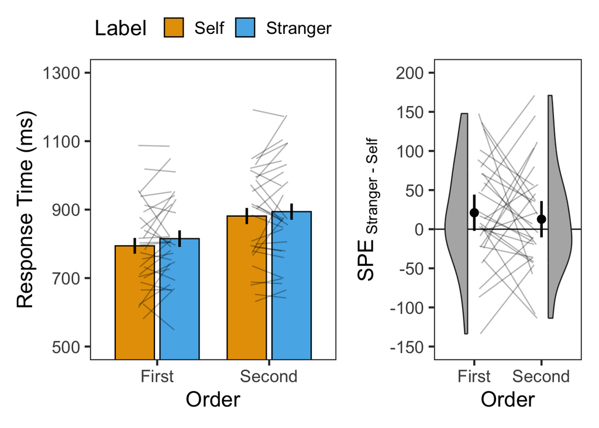

```r
d.same.rt <- dst %>%
  group_by(SN, Order, Label) %>%
  summarise(RT = mean(RT)) %>%
  ungroup()

plotOrderLabel(d.same.rt, "Response Time (ms)", 500, 1300, 200, TRUE, -150, 200, 50)
```

```r
# Descriptive
d.same.rt %>% group_by(Order, Label) %>%
  get_summary_stats(RT, show = c("mean", "sd")) %>%
  kable(digits = 0, format = "simple", caption = "Descriptive summary")
```

Descriptive summary

| Order | Label | variable | n | mean | sd |
| --- | --- | --- | --- | --- | --- |
| First | Self | RT | 28 | 794 | 128 |
| First | Stranger | RT | 28 | 815 | 128 |
| Second | Self | RT | 28 | 881 | 142 |
| Second | Stranger | RT | 28 | 894 | 155 |

```r
# BF
( bf.dRT <- anovaBF(RT ~ Order*Label + SN, data = as.data.frame(d.same.rt),
                    whichRandom = "SN", iterations = nIter, progress = FALSE) )
## Bayes factor analysis
## --------------
## [1] Order + SN                       : 23841276  ±0.3%
## [2] Label + SN                       : 0.3630282 ±0.4%
## [3] Order + Label + SN               : 12536807  ±2.08%
## [4] Order + Label + Order:Label + SN : 3570318   ±2.54%
##
## Against denominator:
##   RT ~ SN
## ---
## Bayes factor type: BFlinearModel, JZS
# plot(bf.dAcc)

# ANOVA
cbind(
  anova_test(
    data = d.same.rt, dv = RT, wid = SN,
    within = c(Order, Label),
    effect.size = "pes") %>%
    get_anova_table() ,
  tibble(BF10 = c( exp((bf.dRT[3]/bf.dRT[2])@bayesFactor$bf),
                   exp((bf.dRT[3]/bf.dRT[1])@bayesFactor$bf),
                   exp((bf.dRT[4]/bf.dRT[3])@bayesFactor$bf) ),
         BF01 = c( exp((bf.dRT[2]/bf.dRT[3])@bayesFactor$bf),
                   exp((bf.dRT[1]/bf.dRT[3])@bayesFactor$bf),
                   exp((bf.dRT[3]/bf.dRT[4])@bayesFactor$bf) ))) %>%
  kable(digits = c(0,0,0,3,5,0,3,3,3), format = "simple", caption = "ANOVA")
```

ANOVA

| Effect | DFn | DFd | F | p | p<.05 | pes | BF10 | BF01 |
| --- | --- | --- | --- | --- | --- | --- | --- | --- |
| Order | 1 | 27 | 29.375 | 0.00001 | * | 0.521 | 34533977.251 | 0.000 |
| Label | 1 | 27 | 2.802 | 0.10600 |  | 0.094 | 0.526 | 1.902 |
| Order:Label | 1 | 27 | 0.266 | 0.61000 |  | 0.010 | 0.285 | 3.511 |

```r
# Post-hoc
dgT <- 3
dgP <- 3
dgM <- 0
dgC <- 0
dgD <- 3
cbind(d.same.rt %>%
        group_by(Order) %>%
        t_test(RT ~ Label, ref.group = "Stranger",
               paired = TRUE, detailed = TRUE) %>%
        adjust_pvalue(method = "bonferroni") %>%
        add_significance("p.adj") %>%
        unite("Comparison", group1:group2, sep = " > ") %>%
        mutate("95% CI" = paste0("[", round(conf.low, digits = dgC), ", ",
                                 round(conf.high, digits = dgC), "]")) %>%
        rename('T' = statistic, M = estimate) %>%
        select(Order, Comparison, 'T', df, p, p.adj, p.adj.signif,
               M, '95% CI'),
      d.same.rt %>%
        group_by(Order) %>%
        cohens_d(RT ~ Label, paired = TRUE, ref.group = "Stranger") %>%
        select("effsize", "magnitude") %>%
        rename("Cohen's d" = effsize)) %>%
  kable(digits = c(0,0,dgT,0,dgP,dgP,0,dgM,0,dgD,0),
        format = "simple", caption = "T-Test, Bonferroni Corrected")
```

T-Test, Bonferroni Corrected

| Order | Comparison | T | df | p | p.adj | p.adj.signif | M | 95% CI | Cohen’s d | magnitude |
| --- | --- | --- | --- | --- | --- | --- | --- | --- | --- | --- |
| First | Stranger > Self | 1.637 | 27 | 0.113 | 0.226 | ns | 21 | [-5, 47] | 0.309 | small |
| Second | Stranger > Self | 0.991 | 27 | 0.331 | 0.662 | ns | 13 | [-14, 39] | 0.187 | negligible |

## 5.3 Label-Matching Accuracy

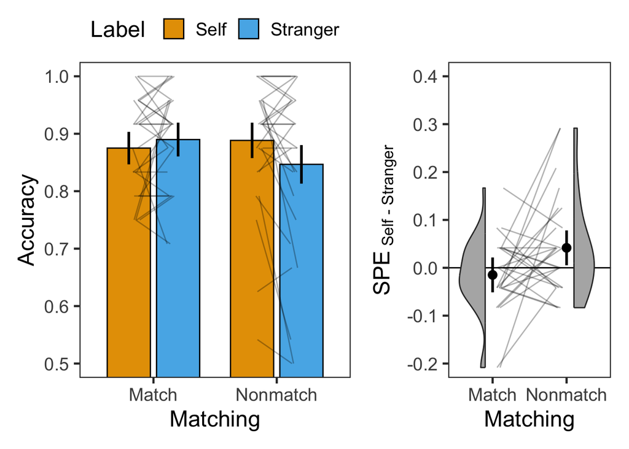

```r
d.spe.acc <- d.spe %>%
  group_by(SN, Matching, Label) %>%
  summarise(Accuracy = mean(Correct)) %>%
  ungroup()

plotMatchLabel(d.spe.acc, "Accuracy", 0.5, 1, .1, FALSE, -.2, .4, .1)
```

```r
# Descriptive
d.spe.acc %>% group_by(Matching, Label) %>%
  get_summary_stats(Accuracy, show = c("mean", "sd")) %>%
  kable(digits = 2, format = "simple", caption = "Descriptive summary")
```

Descriptive summary

| Matching | Label | variable | n | mean | sd |
| --- | --- | --- | --- | --- | --- |
| Match | Self | Accuracy | 28 | 0.88 | 0.09 |
| Match | Stranger | Accuracy | 28 | 0.89 | 0.09 |
| Nonmatch | Self | Accuracy | 28 | 0.89 | 0.11 |
| Nonmatch | Stranger | Accuracy | 28 | 0.85 | 0.15 |

```r
# BF
( bf.dSpeAcc <- anovaBF(Accuracy ~ Matching*Label + SN, data = as.data.frame(d.spe.acc),
                        whichRandom = "SN", iterations = nIter, progress = FALSE) )
## Bayes factor analysis
## --------------
## [1] Matching + SN                          : 0.3058686  ±0.21%
## [2] Label + SN                             : 0.3048416  ±3.72%
## [3] Matching + Label + SN                  : 0.08694748 ±0.54%
## [4] Matching + Label + Matching:Label + SN : 0.1124716  ±2.9%
##
## Against denominator:
##   Accuracy ~ SN
## ---
## Bayes factor type: BFlinearModel, JZS
# plot(bf.dSpeAcc)

# ANOVA
cbind(
  anova_test(
    data = d.spe.acc, dv = Accuracy, wid = SN,
    within = c(Matching, Label),
    effect.size = "pes") %>%
    get_anova_table() ,
  tibble(BF10 = c( exp((bf.dSpeAcc[3]/bf.dSpeAcc[2])@bayesFactor$bf),
                   exp((bf.dSpeAcc[3]/bf.dSpeAcc[1])@bayesFactor$bf),
                   exp((bf.dSpeAcc[4]/bf.dSpeAcc[3])@bayesFactor$bf) ),
         BF01 = c( exp((bf.dSpeAcc[2]/bf.dSpeAcc[3])@bayesFactor$bf),
                   exp((bf.dSpeAcc[1]/bf.dSpeAcc[3])@bayesFactor$bf),
                   exp((bf.dSpeAcc[3]/bf.dSpeAcc[4])@bayesFactor$bf) ))) %>%
  kable(digits = c(0,0,0,3,6,0,3,3,3), format = "simple", caption = "ANOVA")
```

ANOVA

| Effect | DFn | DFd | F | p | p<.05 | pes | BF10 | BF01 |
| --- | --- | --- | --- | --- | --- | --- | --- | --- |
| Matching | 1 | 27 | 0.596 | 0.447 |  | 0.022 | 0.285 | 3.506 |
| Label | 1 | 27 | 1.310 | 0.262 |  | 0.046 | 0.284 | 3.518 |
| Matching:Label | 1 | 27 | 5.074 | 0.033 | * | 0.158 | 1.294 | 0.773 |

```r
# Post-hoc
dgT <- 3
dgP <- 3
dgM <- 3
dgC <- 3
dgD <- 3
cbind(d.spe.acc %>%
        group_by(Matching) %>%
        t_test(Accuracy ~ Label, ref.group = "Self",
               paired = TRUE, detailed = TRUE) %>%
        adjust_pvalue(method = "bonferroni") %>%
        add_significance("p.adj") %>%
        unite("Comparison", group1:group2, sep = " > ") %>%
        mutate("95% CI" = paste0("[", round(conf.low, digits = dgC), ", ",
                                 round(conf.high, digits = dgC), "]")) %>%
        rename('T' = statistic, M = estimate) %>%
        select(Matching, Comparison, 'T', df, p, p.adj, p.adj.signif,
               M, '95% CI'),
      d.spe.acc %>%
        group_by(Matching) %>%
        cohens_d(Accuracy ~ Label, paired = TRUE, ref.group = "Self") %>%
        select("effsize", "magnitude") %>%
        rename("Cohen's d" = effsize)) %>%
  kable(digits = c(0,0,dgT,0,dgP,dgP,0,dgM,0,dgD,0),
        format = "simple", caption = "T-Test, Bonferroni Corrected")
```

T-Test, Bonferroni Corrected

| Matching | Comparison | T | df | p | p.adj | p.adj.signif | M | 95% CI | Cohen’s d | magnitude |
| --- | --- | --- | --- | --- | --- | --- | --- | --- | --- | --- |
| Match | Self > Stranger | -1.000 | 27 | 0.326 | 0.652 | ns | -0.015 | [-0.045, 0.016] | -0.189 | negligible |
| Nonmatch | Self > Stranger | 2.174 | 27 | 0.039 | 0.077 | ns | 0.042 | [0.002, 0.081] | 0.411 | small |

## 5.4 Label-Matching RT

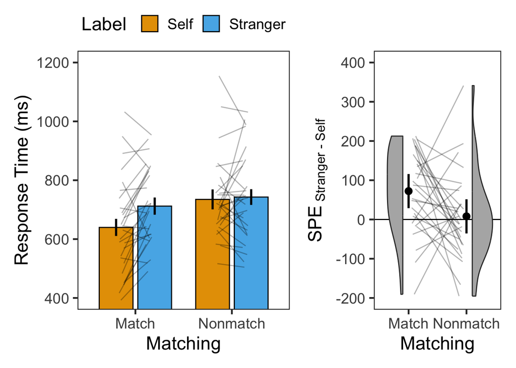

```r
d.spe.rt <- dpt %>%
  group_by(SN, Matching, Label) %>%
  summarise(RT = mean(RT)) %>%
  ungroup()

plotMatchLabel(d.spe.rt, "Response Time (ms)", 400, 1200, 200, TRUE, -200, 400, 100)
```

```r
# Descriptive
d.spe.rt %>% group_by(Matching, Label) %>%
  get_summary_stats(RT, show = c("mean", "sd")) %>%
  kable(digits = 0, format = "simple", caption = "Descriptive summary")
```

Descriptive summary

| Matching | Label | variable | n | mean | sd |
| --- | --- | --- | --- | --- | --- |
| Match | Self | RT | 28 | 640 | 161 |
| Match | Stranger | RT | 28 | 712 | 130 |
| Nonmatch | Self | RT | 28 | 735 | 138 |
| Nonmatch | Stranger | RT | 28 | 743 | 151 |

```r
# BF
( bf.dSpeRT <- anovaBF(RT ~ Matching*Label + SN, data = as.data.frame(d.spe.rt),
                       whichRandom = "SN", iterations = nIter, progress = FALSE) )
## Bayes factor analysis
## --------------
## [1] Matching + SN                          : 203.983  ±0.29%
## [2] Label + SN                             : 2.765072 ±0.19%
## [3] Matching + Label + SN                  : 946.8884 ±0.39%
## [4] Matching + Label + Matching:Label + SN : 1889.554 ±0.95%
##
## Against denominator:
##   RT ~ SN
## ---
## Bayes factor type: BFlinearModel, JZS
# plot(bf.dSpeRT)

# ANOVA
cbind(
  anova_test(
    data = d.spe.rt, dv = RT, wid = SN,
    within = c(Matching, Label),
    effect.size = "pes") %>%
    get_anova_table() ,
  tibble(BF10 = c( exp((bf.dSpeRT[3]/bf.dSpeRT[2])@bayesFactor$bf),
                   exp((bf.dSpeRT[3]/bf.dSpeRT[1])@bayesFactor$bf),
                   exp((bf.dSpeRT[4]/bf.dSpeRT[3])@bayesFactor$bf) ),
         BF01 = c( exp((bf.dSpeRT[2]/bf.dSpeRT[3])@bayesFactor$bf),
                   exp((bf.dSpeRT[1]/bf.dSpeRT[3])@bayesFactor$bf),
                   exp((bf.dSpeRT[3]/bf.dSpeRT[4])@bayesFactor$bf) ))) %>%
  kable(digits = c(0,0,0,3,4,0,3,3,3), format = "simple", caption = "ANOVA")
```

ANOVA

| Effect | DFn | DFd | F | p | p<.05 | pes | BF10 | BF01 |
| --- | --- | --- | --- | --- | --- | --- | --- | --- |
| Matching | 1 | 27 | 18.699 | 0.0002 | * | 0.409 | 342.446 | 0.003 |
| Label | 1 | 27 | 8.181 | 0.0080 | * | 0.233 | 4.642 | 0.215 |
| Matching:Label | 1 | 27 | 4.605 | 0.0410 | * | 0.146 | 1.996 | 0.501 |

```r
# Post-hoc
dgT <- 3
dgP <- 3
dgM <- 0
dgC <- 0
dgD <- 3
cbind(d.spe.rt %>%
        group_by(Matching) %>%
        t_test(RT ~ Label, ref.group = "Stranger",
               paired = TRUE, detailed = TRUE) %>%
        adjust_pvalue(method = "bonferroni") %>%
        add_significance("p.adj") %>%
        unite("Comparison", group1:group2, sep = " > ") %>%
        mutate("95% CI" = paste0("[", round(conf.low, digits = dgC), ", ",
                                 round(conf.high, digits = dgC), "]")) %>%
        rename('T' = statistic, M = estimate) %>%
        select(Matching, Comparison, 'T', df, p, p.adj, p.adj.signif,
               M, '95% CI'),
      d.spe.rt %>%
        group_by(Matching) %>%
        cohens_d(RT ~ Label, paired = TRUE, ref.group = "Stranger") %>%
        select("effsize", "magnitude") %>%
        rename("Cohen's d" = effsize)) %>%
  kable(digits = c(0,0,dgT,0,dgP,dgP,0,dgM,0,dgD,0),
        format = "simple", caption = "T-Test, Bonferroni Corrected")
```

T-Test, Bonferroni Corrected

| Matching | Comparison | T | df | p | p.adj | p.adj.signif | M | 95% CI | Cohen’s d | magnitude |
| --- | --- | --- | --- | --- | --- | --- | --- | --- | --- | --- |
| Match | Stranger > Self | 3.647 | 27 | 0.001 | 0.002 | ** | 72 | [32, 113] | 0.689 | moderate |
| Nonmatch | Stranger > Self | 0.376 | 27 | 0.710 | 1.000 | ns | 8 | [-36, 52] | 0.071 | negligible |

# 6 Correlation

We computed the correlations among self-priority effects (SPE), defined as the difference between stranger RT and self RT, obtained from label-matching RT in the associative learning task, and from shape-matching and label-matching RTs in the working memory task.

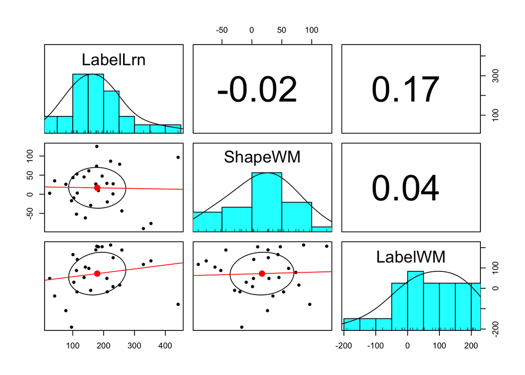

```r
lrn.matching <- s.rt %>%
  filter(Matching == "Match") %>%
  pivot_wider(id_cols = SN, names_from = Label, values_from = RT) %>%
  mutate(LabelLrn = Stranger - Self) %>%
  select(SN, LabelLrn)

tst.wm <- d.same.rt %>%
  group_by(SN, Label) %>%
  summarise(RT = mean(RT)) %>%
  pivot_wider(id_cols = SN, names_from = Label, values_from = RT) %>%
  mutate(ShapeWM = Stranger - Self) %>%
  select(SN, ShapeWM)

tst.matching <- d.spe.rt %>%
  filter(Matching == "Match") %>%
  pivot_wider(id_cols = SN, names_from = Label, values_from = RT) %>%
  mutate(LabelWM = Stranger - Self) %>%
  select(SN, LabelWM)

spe.effects <- full_join(
  full_join(lrn.matching, tst.wm, by = 'SN'),
  tst.matching, by = 'SN')

spe.effects %>%
  select(-SN) %>%
  pairs.panels(lm = TRUE, stars = TRUE)
```

**LabelLrn**: Label-matching SPE in the associative learning task  
**ShapeWM**: Shape-matching SPE in the working memory task  
**LabelWM**: Label-matching SPE in the working memory task

```r
cor.mat <- spe.effects  %>% select(-SN) %>% cor_mat(method = "pearson")
ctb <- cor.mat %>% cor_gather() %>% slice(c(4,7,8)) %>% rename(r = cor)

# BF
( bf.corr1 <- correlationBF(y = spe.effects$LabelLrn, x = spe.effects$ShapeWM) )
## Bayes factor analysis
## --------------
## [1] Alt., r=0.333 : 0.4149212 ±0%
##
## Against denominator:
##   Null, rho = 0
## ---
## Bayes factor type: BFcorrelation, Jeffreys-beta*
( bf.corr2 <- correlationBF(y = spe.effects$LabelLrn, x = spe.effects$LabelWM) )
## Bayes factor analysis
## --------------
## [1] Alt., r=0.333 : 0.5625174 ±0%
##
## Against denominator:
##   Null, rho = 0
## ---
## Bayes factor type: BFcorrelation, Jeffreys-beta*
( bf.corr3 <- correlationBF(y = spe.effects$ShapeWM, x = spe.effects$LabelWM) )
## Bayes factor analysis
## --------------
## [1] Alt., r=0.333 : 0.4201243 ±0%
##
## Against denominator:
##   Null, rho = 0
## ---
## Bayes factor type: BFcorrelation, Jeffreys-beta*

ttb <- tibble(
  var1 = c('LabelLrn', 'LabelLrn', 'ShapeWM'),
  var2 = c('ShapeWM', 'LabelWM', 'LabelWM'),
  BF10 = c( exp(bf.corr1@bayesFactor$bf),
            exp(bf.corr2@bayesFactor$bf),
            exp(bf.corr3@bayesFactor$bf) ),
  BF01 = c( exp((1/bf.corr1)@bayesFactor$bf),
            exp((1/bf.corr2)@bayesFactor$bf),
            exp((1/bf.corr3)@bayesFactor$bf) ))

full_join(ctb, ttb) %>%
  kable(digits = 3, format = "simple",
        caption = "Pearson Correlation Coefficient")
## Joining with `by = join_by(var1, var2)`
```

Pearson Correlation Coefficient

| var1 | var2 | r | p | BF10 | BF01 |
| --- | --- | --- | --- | --- | --- |
| LabelLrn | ShapeWM | -0.025 | 0.900 | 0.415 | 2.410 |
| LabelLrn | LabelWM | 0.170 | 0.390 | 0.563 | 1.778 |
| ShapeWM | LabelWM | 0.042 | 0.831 | 0.420 | 2.380 |

# 7 Session Info

```r
sessionInfo()
## R version 4.5.0 (2025-04-11)
## Platform: aarch64-apple-darwin20
## Running under: macOS Sequoia 15.5
##
## Matrix products: default
## BLAS:   /Library/Frameworks/R.framework/Versions/4.5-arm64/Resources/lib/libRblas.0.dylib
## LAPACK: /Library/Frameworks/R.framework/Versions/4.5-arm64/Resources/lib/libRlapack.dylib;  LAPACK version 3.12.1
##
## locale:
## [1] en_US.UTF-8/en_US.UTF-8/en_US.UTF-8/C/en_US.UTF-8/en_US.UTF-8
##
## time zone: Asia/Seoul
## tzcode source: internal
##
## attached base packages:
## [1] stats     graphics  grDevices utils     datasets  methods   base
##
## other attached packages:
##  [1] klippy_0.0.0.9500      patchwork_1.3.0        cowplot_1.1.3
##  [4] see_0.11.0             ggpubr_0.6.0           gghalves_0.1.4
##  [7] Superpower_0.2.3       BayesFactor_0.9.12-4.7 Matrix_1.7-3
## [10] coda_0.19-4.1          rstatix_0.7.2          knitr_1.50
## [13] psych_2.5.3            lubridate_1.9.4        forcats_1.0.0
## [16] stringr_1.5.1          dplyr_1.1.4            purrr_1.0.4
## [19] readr_2.1.5            tidyr_1.3.1            tibble_3.2.1
## [22] ggplot2_3.5.2          tidyverse_2.0.0
##
## loaded via a namespace (and not attached):
##  [1] tidyselect_1.2.1    viridisLite_0.4.2   farver_2.1.2
##  [4] fastmap_1.2.0       pacman_0.5.1        digest_0.6.37
##  [7] estimability_1.5.1  timechange_0.3.0    lifecycle_1.0.4
## [10] magrittr_2.0.3      compiler_4.5.0      rlang_1.1.6
## [13] sass_0.4.10         tools_4.5.0         utf8_1.2.5
## [16] yaml_2.3.10         ggsignif_0.6.4      labeling_0.4.3
## [19] mnormt_2.1.1        plyr_1.8.9          RColorBrewer_1.1-3
## [22] abind_1.4-8         withr_3.0.2         numDeriv_2016.8-1.1
## [25] grid_4.5.0          afex_1.4-1          xtable_1.8-4
## [28] emmeans_1.11.1      scales_1.4.0        MASS_7.3-65
## [31] insight_1.3.0       cli_3.6.5           mvtnorm_1.3-3
## [34] rmarkdown_2.29      reformulas_0.4.1    generics_0.1.4
## [37] rstudioapi_0.17.1   reshape2_1.4.4      tzdb_0.5.0
## [40] minqa_1.2.8         pbapply_1.7-2       cachem_1.1.0
## [43] splines_4.5.0       assertthat_0.2.1    parallel_4.5.0
## [46] vctrs_0.6.5         boot_1.3-31         jsonlite_2.0.0
## [49] carData_3.0-5       car_3.1-3           hms_1.1.3
## [52] Formula_1.2-5       magick_2.8.6        Rmisc_1.5.1
## [55] jquerylib_0.1.4     glue_1.8.0          nloptr_2.2.1
## [58] stringi_1.8.7       gtable_0.3.6        lme4_1.1-37
## [61] lmerTest_3.1-3      pillar_1.10.2       htmltools_0.5.8.1
## [64] R6_2.6.1            Rdpack_2.6.4        evaluate_1.0.3
## [67] lattice_0.22-7      rbibutils_2.3       backports_1.5.0
## [70] broom_1.0.8         bslib_0.9.0         MatrixModels_0.5-4
## [73] Rcpp_1.0.14         nlme_3.1-168        xfun_0.52
## [76] pkgconfig_2.0.3
```